# 1.Data Acquisition

In this section, we will load a dataset into our Jupyter Notebook.  
In our case, the Automobile Dataset is an online source, and it is in CSV (comma separated value) format.

- data source: https://archive.ics.uci.edu/ml/machine-learning-databases/autos/imports-85.data
- data type: csv

```python
# import pandas library
import pandas as pd
import numpy as np
import matplotlib.pyplot as plt
import seaborn as sns
%matplotlib inline
```

```python
path = "https://projectdata123.s3.jp-tok.cloud-object-storage.appdomain.cloud/auto4.csv"
#path= "C:/Users/SANJANA/Downloads/auto_new.csv"
df = pd.read_csv(path,header = None)

df_copy=df
```

## Read Data

We use `pandas.read_csv()` function to read the csv file. In the bracket, we put the file path along with a quotation mark, so that pandas will read the file into a data frame from that address. The file path can be either an URL or your local file address.  
Because the data does not include headers, we can add an argument `headers = None` inside the `read_csv()` method, so that pandas will not automatically set the first row as a header.

The modified dataset was hosted on our group IBM Cloud object click [HERE](https://projectdata123.s3.jp-tok.cloud-object-storage.appdomain.cloud/auto.csv).

```python
# show the first 5 rows using dataframe.head() method
print("The first 5 rows of the dataframe")
df.head(5)
```

```
The first 5 rows of the dataframe
```

|  | 0 | 1 | 2 | 3 | 4 | 5 | 6 | 7 | 8 | 9 | ... | 16 | 17 | 18 | 19 | 20 | 21 | 22 | 23 | 24 | 25 |
| --- | --- | --- | --- | --- | --- | --- | --- | --- | --- | --- | --- | --- | --- | --- | --- | --- | --- | --- | --- | --- | --- |
| 0 | 3 | ? | alfa-romero | gas | std | two | convertible | rwd | front | 88.6 | ... | 130 | mpfi | 3.47 | 2.68 | 9.0 | 111 | 5000 | 21 | 27 | 13495 |
| 1 | 3 | ? | alfa-romero | gas | std | two | convertible | rwd | front | 88.6 | ... | 130 | mpfi | 3.47 | 2.68 | 9.0 | 111 | 5000 | 21 | 27 | 16500 |
| 2 | 1 | ? | alfa-romero | gas | std | two | hatchback | rwd | front | 94.5 | ... | 152 | mpfi | 2.68 | 3.47 | 9.0 | 154 | 5000 | 19 | 26 | 16500 |
| 3 | 2 | 164 | audi | gas | std | four | sedan | fwd | front | 99.8 | ... | 109 | mpfi | 3.19 | 3.4 | 10.0 | 102 | 5500 | 24 | 30 | 13950 |
| 4 | 2 | 164 | audi | gas | std | four | sedan | 4wd | front | 99.4 | ... | 136 | mpfi | 3.19 | 3.4 | 8.0 | 115 | 5500 | 18 | 22 | 17450 |

5 rows × 26 columns

```python
df.tail(5)
```

|  | 0 | 1 | 2 | 3 | 4 | 5 | 6 | 7 | 8 | 9 | ... | 16 | 17 | 18 | 19 | 20 | 21 | 22 | 23 | 24 | 25 |
| --- | --- | --- | --- | --- | --- | --- | --- | --- | --- | --- | --- | --- | --- | --- | --- | --- | --- | --- | --- | --- | --- |
| 200 | -1 | 95 | volvo | gas | std | four | sedan | rwd | front | 109.1 | ... | 141 | mpfi | 3.78 | 3.15 | 9.5 | 114 | 5400 | 23 | 28 | 16845 |
| 201 | -1 | 95 | volvo | gas | turbo | four | sedan | rwd | front | 109.1 | ... | 141 | mpfi | 3.78 | 3.15 | 8.7 | 160 | 5300 | 19 | 25 | 19045 |
| 202 | -1 | 95 | volvo | gas | std | four | sedan | rwd | front | 109.1 | ... | 173 | mpfi | 3.58 | 2.87 | 8.8 | 134 | 5500 | 18 | 23 | 21485 |
| 203 | -1 | 95 | volvo | diesel | turbo | four | sedan | rwd | front | 109.1 | ... | 145 | idi | 3.01 | 3.4 | 23.0 | 106 | 4800 | 26 | 27 | 22470 |
| 204 | -1 | 95 | volvo | gas | turbo | four | sedan | rwd | front | 109.1 | ... | 141 | mpfi | 3.78 | 3.15 | 9.5 | 114 | 5400 | 19 | 25 | 22625 |

5 rows × 26 columns

```python
# create headers list
headers = ["symboling","normalized-losses","make","fuel-type","aspiration", "num-of-doors","body-style",
         "drive-wheels","engine-location","wheel-base", "length","width","height","curb-weight","engine-type",
         "num-of-cylinders", "engine-size","fuel-system","bore","stroke","compression-ratio","horsepower",
         "peak-rpm","city-mpg","highway-mpg","price"]
print("headers\n", headers)
```

```
headers
 ['symboling', 'normalized-losses', 'make', 'fuel-type', 'aspiration', 'num-of-doors', 'body-style', 'drive-wheels', 'engine-location', 'wheel-base', 'length', 'width', 'height', 'curb-weight', 'engine-type', 'num-of-cylinders', 'engine-size', 'fuel-system', 'bore', 'stroke', 'compression-ratio', 'h…
```

```python
df.columns = headers
df.head(10)
```

|  | symboling | normalized-losses | make | fuel-type | aspiration | num-of-doors | body-style | drive-wheels | engine-location | wheel-base | ... | engine-size | fuel-system | bore | stroke | compression-ratio | horsepower | peak-rpm | city-mpg | highway-mpg | price |
| --- | --- | --- | --- | --- | --- | --- | --- | --- | --- | --- | --- | --- | --- | --- | --- | --- | --- | --- | --- | --- | --- |
| 0 | 3 | ? | alfa-romero | gas | std | two | convertible | rwd | front | 88.6 | ... | 130 | mpfi | 3.47 | 2.68 | 9.0 | 111 | 5000 | 21 | 27 | 13495 |
| 1 | 3 | ? | alfa-romero | gas | std | two | convertible | rwd | front | 88.6 | ... | 130 | mpfi | 3.47 | 2.68 | 9.0 | 111 | 5000 | 21 | 27 | 16500 |
| 2 | 1 | ? | alfa-romero | gas | std | two | hatchback | rwd | front | 94.5 | ... | 152 | mpfi | 2.68 | 3.47 | 9.0 | 154 | 5000 | 19 | 26 | 16500 |
| 3 | 2 | 164 | audi | gas | std | four | sedan | fwd | front | 99.8 | ... | 109 | mpfi | 3.19 | 3.4 | 10.0 | 102 | 5500 | 24 | 30 | 13950 |
| 4 | 2 | 164 | audi | gas | std | four | sedan | 4wd | front | 99.4 | ... | 136 | mpfi | 3.19 | 3.4 | 8.0 | 115 | 5500 | 18 | 22 | 17450 |
| 5 | 2 | ? | audi | gas | std | two | sedan | fwd | front | 99.8 | ... | 136 | mpfi | 3.19 | 3.4 | 8.5 | 110 | 5500 | 19 | 25 | 15250 |
| 6 | 1 | 158 | audi | gas | std | four | sedan | fwd | front | 105.8 | ... | 136 | mpfi | 3.19 | 3.4 | 8.5 | 110 | 5500 | 19 | 25 | 17710 |
| 7 | 1 | ? | audi | gas | std | four | sedan | fwd | front | 105.8 | ... | 136 | mpfi | 3.19 | 3.4 | 8.5 | 110 | 5500 | 19 | 25 | 18920 |
| 8 | 1 | 158 | audi | gas | turbo | four | sedan | fwd | front | 105.8 | ... | 131 | mpfi | 3.13 | 3.4 | 8.3 | 140 | 5500 | 17 | 20 | 23875 |
| 9 | 0 | ? | audi | gas | turbo | two | hatchback | 4wd | front | 99.5 | ... | 131 | mpfi | 3.13 | 3.4 | 7.0 | 160 | 5500 | 16 | 22 | ? |

10 rows × 26 columns

# 2. Data Cleaning

Data Wrangling is the process of converting data from the initial format to a format that may be better for analysis.

As we can see, several question marks appeared in the dataframe; those are missing values which may hinder our further analysis.

Steps we folowed for working with missing data:

1. identify missing data
2. deal with missing data
3. correct data format

#### 1.Identify missing data

In the car dataset, missing data comes with the question mark "?". We replace "?" with NaN (Not a Number), which is Python's default missing value marker, for reasons of computational speed and convenience.

```python
df=df.replace('?',np.NaN)
df.head(5)
```

|  | symboling | normalized-losses | make | fuel-type | aspiration | num-of-doors | body-style | drive-wheels | engine-location | wheel-base | ... | engine-size | fuel-system | bore | stroke | compression-ratio | horsepower | peak-rpm | city-mpg | highway-mpg | price |
| --- | --- | --- | --- | --- | --- | --- | --- | --- | --- | --- | --- | --- | --- | --- | --- | --- | --- | --- | --- | --- | --- |
| 0 | 3 | NaN | alfa-romero | gas | std | two | convertible | rwd | front | 88.6 | ... | 130 | mpfi | 3.47 | 2.68 | 9.0 | 111 | 5000 | 21 | 27 | 13495 |
| 1 | 3 | NaN | alfa-romero | gas | std | two | convertible | rwd | front | 88.6 | ... | 130 | mpfi | 3.47 | 2.68 | 9.0 | 111 | 5000 | 21 | 27 | 16500 |
| 2 | 1 | NaN | alfa-romero | gas | std | two | hatchback | rwd | front | 94.5 | ... | 152 | mpfi | 2.68 | 3.47 | 9.0 | 154 | 5000 | 19 | 26 | 16500 |
| 3 | 2 | 164 | audi | gas | std | four | sedan | fwd | front | 99.8 | ... | 109 | mpfi | 3.19 | 3.4 | 10.0 | 102 | 5500 | 24 | 30 | 13950 |
| 4 | 2 | 164 | audi | gas | std | four | sedan | 4wd | front | 99.4 | ... | 136 | mpfi | 3.19 | 3.4 | 8.0 | 115 | 5500 | 18 | 22 | 17450 |

5 rows × 26 columns

Using a for loop in Python, we can quickly figure out the number of missing values in each column. "True" represents a missing value, "False" means the value is present in the dataset. In the body of the for loop the method ".value_counts()" counts the number of "True" values.

```python
missing_data = df.isnull()
for column in missing_data.columns.values.tolist():
    print(column)
    print (missing_data[column].value_counts())
    print("")
```

```
symboling
False    205
Name: symboling, dtype: int64

normalized-losses
False    164
True      41
Name: normalized-losses, dtype: int64

make
False    205
Name: make, dtype: int64

fuel-type
False    205
Name: fuel-type, dtype: int64

aspiration
False    205
Name: aspiration, dtype: int64

num-of-doors
False    203
True       2
Name: num-of-doors, dtype: int64

body-style
False    205
Name: body-style, dtype: int64

drive-wheels
False    205
Name: drive-wheels, dtype: int64

engine-location
False    205
Name: engine-location, dtype: int64

wheel-base
False    205
```

[output cut: 55 more lines]

```
True       2
Name: peak-rpm, dtype: int64

city-mpg
False    205
Name: city-mpg, dtype: int64

highway-mpg
False    205
Name: highway-mpg, dtype: int64

price
False    201
True       4
Name: price, dtype: int64
```

Based on the summary above, each column has 205 rows of data, seven columns containing missing data:

1. "normalized-losses": 41 missing data
2. "num-of-doors": 2 missing data
3. "bore": 4 missing data
4. "stroke" : 4 missing data
5. "horsepower": 2 missing data
6. "peak-rpm": 2 missing data
7. "price": 4 missing data

### 2.Dealing with missing data

Steps we followed:

1. drop data  
   a. drop the whole row  
   b. drop the whole column
2. replace data  
   a. replace it by mean  
   b. replace it by frequency

**Replacing by mean:**

- "normalized-losses": 41 missing data, replace them with mean
- "stroke": 4 missing data, replace them with mean
- "bore": 4 missing data, replace them with mean
- "horsepower": 2 missing data, replace them with mean
- "peak-rpm": 2 missing data, replace them with mean

```python
avg_norm_loss = df["normalized-losses"].astype(float).mean(axis=0)
print("Average of normalized-losses:", avg_norm_loss)
df["normalized-losses"].replace(np.nan, avg_norm_loss, inplace=True)

avg_bore=df['bore'].astype('float').mean(axis=0)
print("Average of bore:", avg_bore)
df["bore"].replace(np.nan, avg_bore, inplace=True)

df["stroke"].replace(np.nan, df["stroke"].astype(float).mean() , inplace= True)
df["stroke"].head()

avg_horsepower = df['horsepower'].astype(float).mean(axis=0)
print("Average horsepower:", avg_horsepower)
df['horsepower'].replace(np.nan, avg_horsepower, inplace=True)

avg_peakrpm = df['peak-rpm'].astype(float).mean(axis=0)
print("Average peak rpm:", avg_peakrpm)
df['peak-rpm'].replace(np.nan, avg_peakrpm, inplace=True)
```

```
Average of normalized-losses: 122.0
Average of bore: 3.3297512437810957
Average horsepower: 104.25615763546799
Average peak rpm: 5125.369458128079
```

**Replacing by frequency:**

- "num-of-doors": 2 missing data, replace them with "four".
- Reason: 84% sedans is four doors. Since four doors is most frequent, it is most likely to occur

```python
df['num-of-doors'].value_counts()
df['num-of-doors'].value_counts().idxmax()
df["num-of-doors"].replace(np.nan, "four", inplace=True)
```

**Dropping the row:**

- "price": 4 missing data, simply delete the whole row
- Reason: price is what we want to predict. Any data entry without price data cannot be used for prediction; therefore any row now without price data is not useful to us

```python
# simply drop whole row with NaN in "price" column
df.dropna(subset=["price"], axis=0, inplace=True)

# reset index, because we droped two rows
df.reset_index(drop=True, inplace=True)
df.head()
```

|  | symboling | normalized-losses | make | fuel-type | aspiration | num-of-doors | body-style | drive-wheels | engine-location | wheel-base | ... | engine-size | fuel-system | bore | stroke | compression-ratio | horsepower | peak-rpm | city-mpg | highway-mpg | price |
| --- | --- | --- | --- | --- | --- | --- | --- | --- | --- | --- | --- | --- | --- | --- | --- | --- | --- | --- | --- | --- | --- |
| 0 | 3 | 122 | alfa-romero | gas | std | two | convertible | rwd | front | 88.6 | ... | 130 | mpfi | 3.47 | 2.68 | 9.0 | 111 | 5000 | 21 | 27 | 13495 |
| 1 | 3 | 122 | alfa-romero | gas | std | two | convertible | rwd | front | 88.6 | ... | 130 | mpfi | 3.47 | 2.68 | 9.0 | 111 | 5000 | 21 | 27 | 16500 |
| 2 | 1 | 122 | alfa-romero | gas | std | two | hatchback | rwd | front | 94.5 | ... | 152 | mpfi | 2.68 | 3.47 | 9.0 | 154 | 5000 | 19 | 26 | 16500 |
| 3 | 2 | 164 | audi | gas | std | four | sedan | fwd | front | 99.8 | ... | 109 | mpfi | 3.19 | 3.4 | 10.0 | 102 | 5500 | 24 | 30 | 13950 |
| 4 | 2 | 164 | audi | gas | std | four | sedan | 4wd | front | 99.4 | ... | 136 | mpfi | 3.19 | 3.4 | 8.0 | 115 | 5500 | 18 | 22 | 17450 |

5 rows × 26 columns

### Correcting data format

The last step in data wrangling is checking and making sure that all data is in the correct format.

In Pandas, we have used

**.dtype()** to check the data type

**.astype()** to change the data type

```python
df.dtypes
```

```
symboling              int64
normalized-losses     object
make                  object
fuel-type             object
aspiration            object
num-of-doors          object
body-style            object
drive-wheels          object
engine-location       object
wheel-base           float64
length               float64
width                float64
height               float64
curb-weight            int64
engine-type           object
num-of-cylinders      object
engine-size            int64
fuel-system           object
bore                  object
stroke                object
compression-ratio    float64
horsepower            object
peak-rpm              object
city-mpg               int64
highway-mpg            int64
price                 object
dtype: object
```

```python
df[["bore", "stroke"]] = df[["bore", "stroke"]].astype(float)
df[["normalized-losses"]] = df[["normalized-losses"]].astype(int)
df[["price"]] = df[["price"]].astype(float)
df[["peak-rpm"]] = df[["peak-rpm"]].astype(float)
df["horsepower"]=df["horsepower"].astype(float, copy=True)
df.dtypes
```

```
symboling              int64
normalized-losses      int32
make                  object
fuel-type             object
aspiration            object
num-of-doors          object
body-style            object
drive-wheels          object
engine-location       object
wheel-base           float64
length               float64
width                float64
height               float64
curb-weight            int64
engine-type           object
num-of-cylinders      object
engine-size            int64
fuel-system           object
bore                 float64
stroke               float64
compression-ratio    float64
horsepower           float64
peak-rpm             float64
city-mpg               int64
highway-mpg            int64
price                float64
dtype: object
```

#### Data Transformation & Standardization

Transforming mpg to L/100km:

In our dataset, the fuel consumption columns "city-mpg" and "highway-mpg" are represented by mpg (miles per gallon) unit. But the fuel consumption L/100km is standard

We will need to apply **data transformation** to transform mpg into L/100km?

```python
# Converting mpg to L/100km by mathematical operation (235 divided by mpg)
df['city-L/100km'] = 235/df["city-mpg"]
df.drop(columns="city-mpg",axis =1, inplace=True)
# transforming mpg to L/100km by mathematical operation (235 divided by mpg)
df["highway-mpg"] = 235/df["highway-mpg"]
# renaming column name from "highway-mpg" to "highway-L/100km"
df.rename(columns={"highway-mpg":'highway-L/100km'}, inplace=True)
# checking your transformed data
df.head()
```

|  | symboling | normalized-losses | make | fuel-type | aspiration | num-of-doors | body-style | drive-wheels | engine-location | wheel-base | ... | engine-size | fuel-system | bore | stroke | compression-ratio | horsepower | peak-rpm | highway-L/100km | price | city-L/100km |
| --- | --- | --- | --- | --- | --- | --- | --- | --- | --- | --- | --- | --- | --- | --- | --- | --- | --- | --- | --- | --- | --- |
| 0 | 3 | 122 | alfa-romero | gas | std | two | convertible | rwd | front | 88.6 | ... | 130 | mpfi | 3.47 | 2.68 | 9.0 | 111.0 | 5000.0 | 8.703704 | 13495.0 | 11.190476 |
| 1 | 3 | 122 | alfa-romero | gas | std | two | convertible | rwd | front | 88.6 | ... | 130 | mpfi | 3.47 | 2.68 | 9.0 | 111.0 | 5000.0 | 8.703704 | 16500.0 | 11.190476 |
| 2 | 1 | 122 | alfa-romero | gas | std | two | hatchback | rwd | front | 94.5 | ... | 152 | mpfi | 2.68 | 3.47 | 9.0 | 154.0 | 5000.0 | 9.038462 | 16500.0 | 12.368421 |
| 3 | 2 | 164 | audi | gas | std | four | sedan | fwd | front | 99.8 | ... | 109 | mpfi | 3.19 | 3.40 | 10.0 | 102.0 | 5500.0 | 7.833333 | 13950.0 | 9.791667 |
| 4 | 2 | 164 | audi | gas | std | four | sedan | 4wd | front | 99.4 | ... | 136 | mpfi | 3.19 | 3.40 | 8.0 | 115.0 | 5500.0 | 10.681818 | 17450.0 | 13.055556 |

5 rows × 26 columns

#### Data Normalization

we are scaling the columns "length", "width" and "height" </p>

**Target:**we would like to Normalize those variables so their value ranges from 0 to 1.

**Approach:** Simple Feature Scaling ,replacing original value by (original value)/(maximum value)

```python
# replace (original value) by (original value)/(maximum value) simple feature scaling
df['length'] = df['length']/df['length'].max()
df['width'] = df['width']/df['width'].max()
df['height'] = df['height']/df['height'].max()
df[["length","width","height"]].head()
```

|  | length | width | height |
| --- | --- | --- | --- |
| 0 | 0.811148 | 0.890278 | 0.816054 |
| 1 | 0.811148 | 0.890278 | 0.816054 |
| 2 | 0.822681 | 0.909722 | 0.876254 |
| 3 | 0.848630 | 0.919444 | 0.908027 |
| 4 | 0.848630 | 0.922222 | 0.908027 |

#### Binning

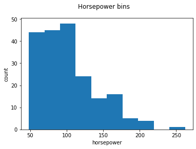

```python
df["horsepower"].plot(kind='hist')
# set x/y labels and plot title
plt.xlabel("horsepower")
plt.ylabel("count")
plt.suptitle("Horsepower bins")
```

```python
bins = np.linspace(min(df["horsepower"]), max(df["horsepower"]), 4)
bins
```

```
array([ 48.        , 119.33333333, 190.66666667, 262.        ])
```

```python
group_names = ['Low', 'Medium', 'High']
df['horsepower-binned'] = pd.cut(df['horsepower'], bins, labels=group_names, include_lowest=True )
df["horsepower-binned"].value_counts().to_frame()
```

|  | horsepower-binned |
| --- | --- |
| Low | 153 |
| Medium | 43 |
| High | 5 |

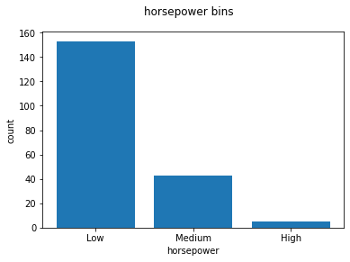

```python
plt.bar(group_names, df["horsepower-binned"].value_counts())

# set x/y labels and plot title
plt.xlabel("horsepower")
plt.ylabel("count")
plt.suptitle("horsepower bins")
```

The last column provides the bins for "horsepower" with 3 categories ("Low","Medium" and "High").

We successfully narrow the intervals from 57 to 3!

#### Indicator variable (or dummy variable)

An indicator variable (or dummy variable) is a numerical variable used to label categories. They are called 'dummies' because the numbers themselves don't have inherent meaning.

the column "fuel-type" has two unique values, "gas" or "diesel". Regression doesn't understand words, only numbers. To use this attribute in regression analysis, we converted "fuel-type" into indicator variables.

We used the panda's method 'get_dummies' to assign numerical values to different categories of fuel type.

```python
dummy_variable_1 = pd.get_dummies(df["fuel-type"])
dummy_variable_1.head()
```

|  | diesel | gas |
| --- | --- | --- |
| 0 | 0 | 1 |
| 1 | 0 | 1 |
| 2 | 0 | 1 |
| 3 | 0 | 1 |
| 4 | 0 | 1 |

```python
dummy_variable_1.rename(columns={'gas':'fuel-type-gas', 'diesel':'fuel-type-diesel'}, inplace=True)
# merge data frame "df" and "dummy_variable_1"
df = pd.concat([df, dummy_variable_1], axis=1)
# drop original column "fuel-type" from "df"
df.drop("fuel-type", axis = 1, inplace=True)
df.head()
```

|  | symboling | normalized-losses | make | aspiration | num-of-doors | body-style | drive-wheels | engine-location | wheel-base | length | ... | stroke | compression-ratio | horsepower | peak-rpm | highway-L/100km | price | city-L/100km | horsepower-binned | fuel-type-diesel | fuel-type-gas |
| --- | --- | --- | --- | --- | --- | --- | --- | --- | --- | --- | --- | --- | --- | --- | --- | --- | --- | --- | --- | --- | --- |
| 0 | 3 | 122 | alfa-romero | std | two | convertible | rwd | front | 88.6 | 0.811148 | ... | 2.68 | 9.0 | 111.0 | 5000.0 | 8.703704 | 13495.0 | 11.190476 | Low | 0 | 1 |
| 1 | 3 | 122 | alfa-romero | std | two | convertible | rwd | front | 88.6 | 0.811148 | ... | 2.68 | 9.0 | 111.0 | 5000.0 | 8.703704 | 16500.0 | 11.190476 | Low | 0 | 1 |
| 2 | 1 | 122 | alfa-romero | std | two | hatchback | rwd | front | 94.5 | 0.822681 | ... | 3.47 | 9.0 | 154.0 | 5000.0 | 9.038462 | 16500.0 | 12.368421 | Medium | 0 | 1 |
| 3 | 2 | 164 | audi | std | four | sedan | fwd | front | 99.8 | 0.848630 | ... | 3.40 | 10.0 | 102.0 | 5500.0 | 7.833333 | 13950.0 | 9.791667 | Low | 0 | 1 |
| 4 | 2 | 164 | audi | std | four | sedan | 4wd | front | 99.4 | 0.848630 | ... | 3.40 | 8.0 | 115.0 | 5500.0 | 10.681818 | 17450.0 | 13.055556 | Low | 0 | 1 |

5 rows × 28 columns

## Border Detection Algorithm

```python
#df['convertible'].unique()

db = df["body-style"].tolist()

print(db)
#df['body-style'].describe(include=object)
```

```
['convertible', 'convertible', 'hatchback', 'sedan', 'sedan', 'sedan', 'sedan', 'sedan', 'sedan', 'sedan', 'sedan', 'sedan', 'sedan', 'sedan', 'sedan', 'sedan', 'sedan', 'hatchback', 'hatchback', 'sedan', 'hatchback', 'hatchback', 'hatchback', 'hatchback', 'sedan', 'sedan', 'sedan', 'sedan', 'hatchb…
```

```python
# The BorderDetection Algorithm

'''
    Function to compute qgrams().
    It takes a single string as i/p and returns a list with qgrams
'''

import random
import operator
from itertools import groupby

def qgrams(str,n) :
    modstr = '#' + str + '$'
    b = []
    #print(modstr)
    for i in range(len(modstr)-n+1) :
        qgr = modstr[i:i+n]
        #print(qgr)
        b.append(qgr)

    #print(b)
    return b

'''
    Function to compute inverse strings.
    It returns the list of indexes containing the given qgram.
'''
def inverse_strings(qgr,db) :
    res = []
    Bag = []
    for alpha in db :
        Bag = qgrams(alpha,n)
        if qgr in Bag :
            res.append(db.index(alpha))
    return res


def intersection(list1,list2) :
    return list(set(list1) & set(list2))


def union(list1,list2) :
    return list(set(list1) | set(list2))

def overlapStrings(tp) :
    overlap = []
    overlap = inverse_strings(tp[0],db)
    for ki in tp :
        inv_str = inverse_strings(ki,db)
        overlap = intersection(overlap,inv_str)

    #print(overlap)
    return overlap

def count_qgrams(seq) -> dict:
    hist = {}
    for i in seq :
        hist[i] = hist.get(i,0)+1

    return hist


def extract_bag(hist,size) :
    bag = []
    for key in hist.keys():
        bag.append(key)

    return bag[:size]


'''
This function counts the longest sequence in the input list
and returns the index of the 1st occurence of sub-sequence.

'''
def maxoccur(cl) :
    temp = groupby(cl)
    res = max(temp, key = lambda sub: len(list(sub[1])))
    #print(res)

    num_times, occurrence = max((len(list(values)), key) for key, values in groupby(cl))
    # - print("%d occurred %d times" % (occurrence, num_times))

    for i in cl :
        if i == occurrence :
            ind = cl.index(i)
            t= ind
            for j in range(num_times) :
                #assert cl[t]==occurrence
                t=t+1

    # - print(ind)
    return ind

'''
Function to convert q-grams to string
'''
def qgrams_to_strings(some_list,n) :
    str = ""
    for q in some_list :
        str += q[:n-1]
        qgram_length = len(q)


    if(str[0]=='#') :
        str = str[1:]

    if str[len(str)-1]=='$' :
        str = str[:-1]

    if(str[0]=='#' and str[len(str)-1]=='$') :
        str = str[1:-1]

    #print(str)
    return str

def rectify_qgrams(baglist) :
    if baglist[0].startswith('#') and baglist[len(baglist)-1].endswith('$') :
        return baglist
    else :
        ctr = 0
        for q in baglist :

            if q.startswith('#') :
                baglist.insert(0,baglist.pop(ctr))
            if q.endswith('$') :
                baglist.append(baglist.pop(ctr))
            ctr +=1

        print(baglist)
        return baglist

# Begining of algorithm
#db = ['jacob','yacob','jacob','jacob','jacob','jaxob','sydney','sydney','sydnoy','sydney','sydnay','sydney']
#db = ['kolkata','kolkata','kolkata','kolkota','kalkata','kolkata','delhi','delhi','delli','dilli','delhi','delhi']

# copy of database
db_copy = []
for i in db :
    db_copy.append(i)


n = 2
S = 5

# Initializing
clustered_strings = []
clusters = []

#IS = []
cluster = {}

#O_content = []
#histogram_dict = {}
#hist_list = []

# Calling the func qgrams on every string in the database here.
for alpha in db :
    #print(type(alpha))
    if alpha in clustered_strings :
        continue
    else :
        #B = []
        B = qgrams(alpha,n)

        # max border
        bm = len(B)

        # Initializing current cluster
        O = []

        for o in reversed(range(1,bm)) :  # 2.2
            #print(o)
            #k = []  #to store all the sample tuples

            for i in range(1,S+1) : # 2.2.1
                tup = [] # to store one randomly generated tuple

                while len(tup) != o :  # 2.2.1.1
                    ki = random.choice(B)
                    if ki in tup :
                        continue
                    else :
                        tup.append(ki)
                tp = tuple(tup)  # one tuple generated here
                # - print(tp)

                overlap = overlapStrings(tp) # 2.2.1.2
                # - print(overlap)


                O = union(O,overlap)


            #print('Union of threshold value '+ str(o))
            # - print("union of threshold value :")
            # - print(O)
            # - print('\n\n')

             #print("Center bag changes")

            # 2.2.2
            # - print("Updating the center of cluster now")

            # collecting the contents of indexed O
            O_content = []
            histogram_dict = {}
            hist_list = []

            for i in O :
                O_content.append(db[i])

            # 2.2.2.1
            sum_a = 0
            for a in O_content :
                # - print(a)
                # Changing center bag here itsef ( !! Not sure)
                B = qgrams(a,2)
                sum_a += len(B)
                for k in B :
                    #histogram_dict[k].append(1)
                    # forming a tuple to calculate histogram
                    hist_list.append(k)

            # - print(hist_list)
            histogram_dict = count_qgrams(hist_list)
            #print(histogram_dict)

            # 2.2.2.2  ( to sort histogram_dict by values )
            sorted_hist = dict(sorted(histogram_dict.items(), key=operator.itemgetter(1),reverse=True))
            # - print(sorted_hist)

            # 2.2.2.3
            A = int(sum_a/len(O_content))
            # - print(A)
            #print(O_content)

            # 2.2.2.4
            B = extract_bag(sorted_hist,A)
            # - print(B)

            # 2.2.3
            cluster[o] = B

        # 2.3
        # - print("Printing the cluster[]\n")
        # - print(cluster)
        # finding the longest sequence ib to ib + delta
        cluster_len = []
        for key in cluster :
            cluster_len.append(len(cluster[key]))

        # - print(cluster_len)  # contains the length of all the elements

        #longest_sequence(cluster_len)
        index_ib = maxoccur(cluster_len) # gives the index of the occurence of longest sequence

        # 2.4 update clustered_strings
        cluster_values = list(cluster.values())
        cluster_ib_list = cluster_values[index_ib]
        # - print(cluster_ib_list)

        #clustered_strings.append(cluster_ib_list)
        #print(clustered_strings)
        cluster_ib_str = qgrams_to_strings(cluster_ib_list,2)
        clustered_strings.append(cluster_ib_str)
        #  - print("printing clustered strings : ")
        # - print(clustered_strings)


        # 2.5 updating clusters
        clusters.append(cluster_ib_list)
        #clusters = union(clusters,cluster_ib_list)
        # - print(clusters)

        # 2.6 emptying h[k], O, B
        B = []
        O = []
        histogram_dict = {}
        sorted_hist = {}
        hist_list = []

# 3
# printing the clusters only
print("Clusters formed are: ")
# - print(clusters)

indexlist = []
new_clust = []  # to store the clusters in a list

for i in range(len(clusters)) :
    ci = clusters[i]
    clust_i = []    # to store the current formed cluster ci
    if i not in indexlist :
        clust_i.append(ci)

    for j in range(i+1,len(clusters)) :
        cj = clusters[j]
        intersect = intersection(ci,cj)

        if len(intersect)!= 0 and j not in indexlist :
            # print(intersection(ci,cj))
            clust_i.append(cj)
            indexlist.append(j)

    #print(clust_i)

    if len(clust_i) != 0 :
        new_clust.append(clust_i)



# Printing the clusters formed
for i in new_clust :
    print(i)


# Converting the clusters to string and correcting the clusters
new_stringClust = []
new_corrected_clust = []
print("Correcting the clusters to an extent : ")
for i in new_clust :
    new_stringList = []
    new_corrected_list = []
    for j in i :
        #i[j] = rectify_qgrams(j)
        temp = rectify_qgrams(j)
        new_stringList.append(qgrams_to_strings(temp,n))
        new_corrected_list.append(temp)
    new_stringClust.append(new_stringList)
    new_corrected_clust.append(new_corrected_list)

# printing modified clusters
for i in new_stringClust :
    print(i)

'''
# printing corrected cluster
for i in new_corrected_clust :
    print(i)
'''

print("Correct spelling for each Cluster : ")
# 4
# Counting frequency of each qgram

freq_dict = {}  # to count the frequency of each qgram
correct_str_list = []

for c in new_corrected_clust :
    #print(c)
    new_list = []
    sum_freq = 0
    #qgram_list = []
    for element in c :
        #xyz = count_qgrams(element)
        sum_freq+= len(element)
        for q in element :
            new_list.append(q)

        # rectify the qgrams
        #rectify_qgrams(element)

    freq_dict = count_qgrams(new_list)
    # - print(freq_dict)
    length = int(sum_freq/len(c))

    #sorted_hist2 = dict(sorted(freq_dict.items(), key=operator.itemgetter(1),reverse=True))
    #print(sorted_hist2)


    qgram_list = list(freq_dict.keys())
    #qgram_list = list(sorted_hist2.keys())
    #print(qgram_list)

    # Rectifying the sorted histogram
    #x = rectify_qgrams(qgram_list)
    #print(x)

    correct_str = qgrams_to_strings(qgram_list[:length],n)
    print(correct_str)
    correct_str_list.append(correct_str)



# check length of corrected_Strings and clusters formed
assert len(correct_str_list)==len(new_clust)
```

```
Clusters formed are:
[['#c', 'co', 'on', 'nv', 've', 'er', 'rt', 'ti', 'ib', 'bl', 'le', 'e$']]
[['#h', 'ha', 'at', 'tc', 'ch', 'hb', 'ba', 'ac', 'ck', 'k$'], ['#h', 'ha', 'at', 'tc', 'ch', 'hi', 'ia', 'ac', 'ck', 'k$']]
[['#s', 'se', 'ed', 'da', 'an', 'n$'], ['#s', 'se', 'ex', 'xa', 'an', 'n$']]
Correcting the clusters to an extent :
['convertible']
['hatchback', 'hatchiack']
['sedan', 'sexan']
Correct spelling for each Cluster :
convertible
hatchback
sedan
```

```python
# rectify the db_copy

db_count = 0
for s in db_copy :
    #print(s)
    index_count = 0
    for cl in new_stringClust :
        #print(cl)
        if s in cl :
            db_copy.pop(db_count)
            db_copy.insert(db_count,correct_str_list[index_count])

        index_count += 1
    db_count += 1

print("Cleaned List of Database is : ")
print(db_copy)
```

```
Cleaned List of Database is :
['convertible', 'convertible', 'hatchback', 'sedan', 'sedan', 'sedan', 'sedan', 'sedan', 'sedan', 'sedan', 'sedan', 'sedan', 'sedan', 'sedan', 'sedan', 'sedan', 'sedan', 'hatchback', 'hatchback', 'sedan', 'hatchback', 'hatchback', 'hatchback', 'hatchback', 'sedan', 'sedan', 'sedan', 'sedan', 'hatchb…
```

```python
df = pd.concat([df, pd.DataFrame(db_copy)], axis=1)
df.drop('body-style', axis=1,inplace=True)
df.rename(columns={0:'body-style'}, inplace=True)

df.head()
```

|  | symboling | normalized-losses | make | aspiration | num-of-doors | drive-wheels | engine-location | wheel-base | length | width | ... | compression-ratio | horsepower | peak-rpm | highway-L/100km | price | city-L/100km | horsepower-binned | fuel-type-diesel | fuel-type-gas | body-style |
| --- | --- | --- | --- | --- | --- | --- | --- | --- | --- | --- | --- | --- | --- | --- | --- | --- | --- | --- | --- | --- | --- |
| 0 | 3 | 122 | alfa-romero | std | two | rwd | front | 88.6 | 0.811148 | 0.890278 | ... | 9.0 | 111.0 | 5000.0 | 8.703704 | 13495.0 | 11.190476 | Low | 0 | 1 | convertible |
| 1 | 3 | 122 | alfa-romero | std | two | rwd | front | 88.6 | 0.811148 | 0.890278 | ... | 9.0 | 111.0 | 5000.0 | 8.703704 | 16500.0 | 11.190476 | Low | 0 | 1 | convertible |
| 2 | 1 | 122 | alfa-romero | std | two | rwd | front | 94.5 | 0.822681 | 0.909722 | ... | 9.0 | 154.0 | 5000.0 | 9.038462 | 16500.0 | 12.368421 | Medium | 0 | 1 | hatchback |
| 3 | 2 | 164 | audi | std | four | fwd | front | 99.8 | 0.848630 | 0.919444 | ... | 10.0 | 102.0 | 5500.0 | 7.833333 | 13950.0 | 9.791667 | Low | 0 | 1 | sedan |
| 4 | 2 | 164 | audi | std | four | 4wd | front | 99.4 | 0.848630 | 0.922222 | ... | 8.0 | 115.0 | 5500.0 | 10.681818 | 17450.0 | 13.055556 | Low | 0 | 1 | sedan |

5 rows × 28 columns

# 3.Exploratory Data Analysis

1. Steps we follow for two types of data here :
   - Continuous numerical variables
   - Categorical variables
2. Descriptive Statistical Analysis

```python
df.columns
```

```
Index(['symboling', 'normalized-losses', 'make', 'aspiration', 'num-of-doors',
       'drive-wheels', 'engine-location', 'wheel-base', 'length', 'width',
       'height', 'curb-weight', 'engine-type', 'num-of-cylinders',
       'engine-size', 'fuel-system', 'bore', 'stroke', 'compression-ratio',
       'horsepower', 'peak-rpm', 'highway-L/100km', 'price', 'city-L/100km',
       'horsepower-binned', 'fuel-type-diesel', 'fuel-type-gas', 'body-style'],
      dtype='object')
```

**1. Continuous numerical variables**

Continuous numerical variables are variables that may contain any value within some range. Continuous numerical variables can have the type "int64" or "float64".

In order to start understanding the (linear) relationship between an individual variable and the price. We can do this by using "regplot" from seaborn, which plots the scatterplot plus the fitted regression line for the data.

|  | normalized-losses | price |
| --- | --- | --- |
| normalized-losses | 1.000000 | 0.133999 |
| price | 0.133999 | 1.000000 |

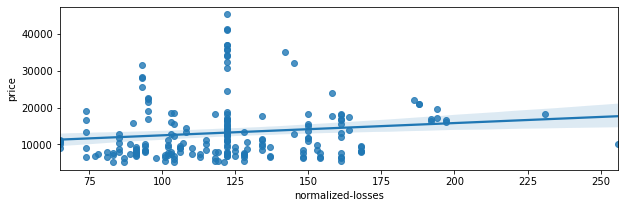

```python
# normalized-losses not a potential predictor variable of price
fig_dims = (10, 3)
fig, ax = plt.subplots(figsize=fig_dims)
sns.regplot(x="normalized-losses", y="price",ax=ax, data= df)
plt.title ="Engine size as potential predictor variable of price"
df[["normalized-losses", "price"]].corr()
```

|  | engine-size | price |
| --- | --- | --- |
| engine-size | 1.000000 | 0.872335 |
| price | 0.872335 | 1.000000 |

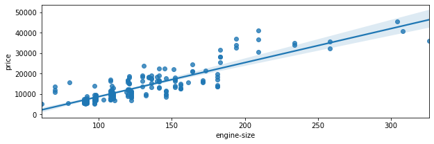

```python
# Engine size as potential predictor variable of price
fig_dims = (10, 3)
fig, ax = plt.subplots(figsize=fig_dims)
sns.regplot(x="engine-size", y="price", ax=ax,data= df)
plt.title ="Engine size as potential predictor variable of price"
df[["engine-size", "price"]].corr()
```

|  | peak-rpm | price |
| --- | --- | --- |
| peak-rpm | 1.000000 | -0.101616 |
| price | -0.101616 | 1.000000 |

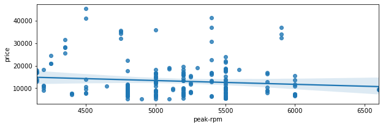

```python
fig_dims = (10, 3)
fig, ax = plt.subplots(figsize=fig_dims)
sns.regplot(x="peak-rpm", y="price",ax=ax, data=df)
plt.title ="peak-rpm is not a potential predictor variable of price"
df[["peak-rpm", "price"]].corr()
```

|  | stroke | price |
| --- | --- | --- |
| stroke | 1.000000 | 0.082269 |
| price | 0.082269 | 1.000000 |

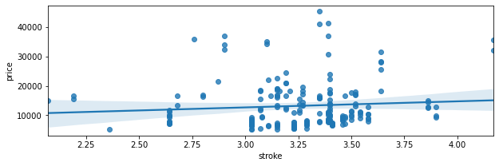

```python
fig_dims = (10, 3)
fig, ax = plt.subplots(figsize=fig_dims)
sns.regplot(x="stroke", y="price",ax=ax, data=df)
plt.title ="stroke is not a potential predictor variable of price"
df[["stroke","price"]].corr()
```

|  | highway-L/100km | price |
| --- | --- | --- |
| highway-L/100km | 1.000000 | 0.801118 |
| price | 0.801118 | 1.000000 |

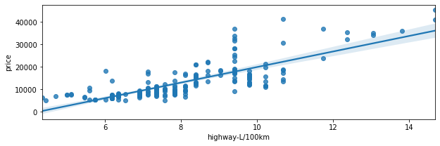

```python
fig_dims = (10, 3)
fig, ax = plt.subplots(figsize=fig_dims)
sns.regplot(x="highway-L/100km", y="price", ax=ax,data=df)
plt.title ="highway-L/100km as potential predictor variable of price"
df[["highway-L/100km", "price"]].corr()
```

**2.Categorical variables**

These are variables that describe a 'characteristic' of a data unit, and are selected from a small group of categories. The categorical variables can have the type "object" or "int64".

We used boxplot from seaborn to visualize categorical data.

if the distributions of price between the different categorical variables have a significant overlap,then it would not be a good predictor of price.

|  | symboling | price |
| --- | --- | --- |
| symboling | 1.000000 | -0.082391 |
| price | -0.082391 | 1.000000 |

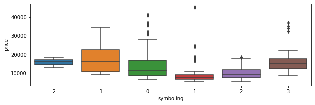

```python
fig_dims = (10, 3)
fig, ax = plt.subplots(figsize=fig_dims)
sns.boxplot(x="symboling", y="price",ax=ax, data= df)
plt.title ="symboling as potential predictor variable of price"
df[["symboling", "price"]].corr()
```

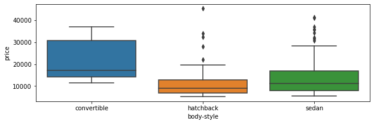

```python
fig_dims = (10, 3)
fig, ax = plt.subplots(figsize=fig_dims)
sns.boxplot(x="body-style", y="price",ax=ax, data=df)
plt.title =" body-style as potential predictor variable of price"
```

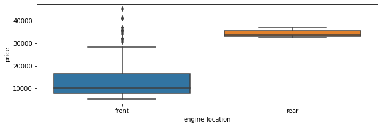

```python
fig_dims = (10, 3)
fig, ax = plt.subplots(figsize=fig_dims)
sns.boxplot(x="engine-location", y="price",ax=ax, data=df)
plt.title =" body-style as potential predictor variable of price"
```

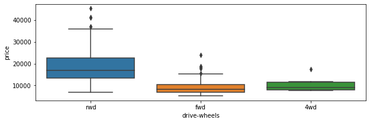

```python
# drive-wheels
fig_dims = (10, 3)
fig, ax = plt.subplots(figsize=fig_dims)
sns.boxplot(x="drive-wheels", y="price",ax=ax, data=df)
plt.title="make as potential predictor variable of price"
```

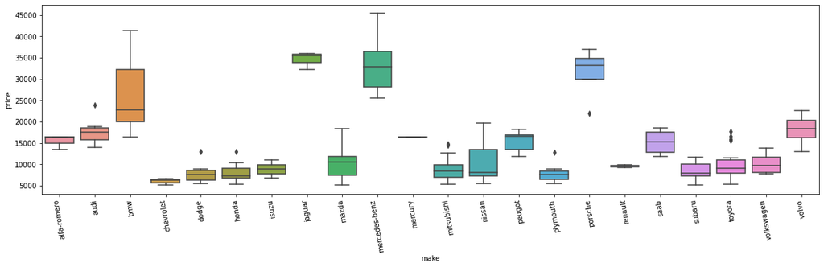

```python
fig_dims = (20, 5)
fig, ax = plt.subplots(figsize=fig_dims)
sns.boxplot(x="make", y="price",  ax=ax, data=df)
plt.xticks(rotation='100')
plt.title="make as potential predictor variable of price"
```

Taking a look at the variables by utilizing a description method.

The **describe** function automatically computes basic statistics for all continuous variables. Any NaN v alues are automatically skipped in these statistics.

This will show:

- the count of that variable
- the mean
- the standard deviation (std)
- the minimum value
- the IQR (Interquartile Range: 25%, 50% and 75%)
- the maximum value

```python
df.describe()
```

|  | symboling | normalized-losses | wheel-base | length | width | height | curb-weight | engine-size | bore | stroke | compression-ratio | horsepower | peak-rpm | highway-L/100km | price | city-L/100km | fuel-type-diesel | fuel-type-gas |
| --- | --- | --- | --- | --- | --- | --- | --- | --- | --- | --- | --- | --- | --- | --- | --- | --- | --- | --- |
| count | 201.000000 | 201.00000 | 201.000000 | 201.000000 | 201.000000 | 201.000000 | 201.000000 | 201.000000 | 201.000000 | 201.000000 | 201.000000 | 201.000000 | 201.000000 | 201.000000 | 201.000000 | 201.000000 | 201.000000 | 201.000000 |
| mean | 0.840796 | 122.00000 | 98.797015 | 0.837102 | 0.915126 | 0.899108 | 2555.666667 | 126.875622 | 3.330692 | 3.256874 | 10.164279 | 103.405534 | 5117.665368 | 8.044957 | 13207.129353 | 9.944145 | 0.099502 | 0.900498 |
| std | 1.254802 | 31.99625 | 6.066366 | 0.059213 | 0.029187 | 0.040933 | 517.296727 | 41.546834 | 0.268072 | 0.316048 | 4.004965 | 37.365700 | 478.113805 | 1.840739 | 7947.066342 | 2.534599 | 0.300083 | 0.300083 |
| min | -2.000000 | 65.00000 | 86.600000 | 0.678039 | 0.837500 | 0.799331 | 1488.000000 | 61.000000 | 2.540000 | 2.070000 | 7.000000 | 48.000000 | 4150.000000 | 4.351852 | 5118.000000 | 4.795918 | 0.000000 | 0.000000 |
| 25% | 0.000000 | 101.00000 | 94.500000 | 0.801538 | 0.890278 | 0.869565 | 2169.000000 | 98.000000 | 3.150000 | 3.110000 | 8.600000 | 70.000000 | 4800.000000 | 6.911765 | 7775.000000 | 7.833333 | 0.000000 | 1.000000 |
| 50% | 1.000000 | 122.00000 | 97.000000 | 0.832292 | 0.909722 | 0.904682 | 2414.000000 | 120.000000 | 3.310000 | 3.290000 | 9.000000 | 95.000000 | 5125.369458 | 7.833333 | 10295.000000 | 9.791667 | 0.000000 | 1.000000 |
| 75% | 2.000000 | 137.00000 | 102.400000 | 0.881788 | 0.925000 | 0.928094 | 2926.000000 | 141.000000 | 3.580000 | 3.410000 | 9.400000 | 116.000000 | 5500.000000 | 9.400000 | 16500.000000 | 12.368421 | 0.000000 | 1.000000 |
| max | 3.000000 | 256.00000 | 120.900000 | 1.000000 | 1.000000 | 1.000000 | 4066.000000 | 326.000000 | 3.940000 | 4.170000 | 23.000000 | 262.000000 | 6600.000000 | 14.687500 | 45400.000000 | 18.076923 | 1.000000 | 1.000000 |

```python
df.describe(include='object')
```

|  | make | aspiration | num-of-doors | drive-wheels | engine-location | engine-type | num-of-cylinders | fuel-system | body-style |
| --- | --- | --- | --- | --- | --- | --- | --- | --- | --- |
| count | 201 | 201 | 201 | 201 | 201 | 201 | 201 | 201 | 201 |
| unique | 22 | 2 | 2 | 3 | 2 | 6 | 7 | 8 | 3 |
| top | toyota | std | four | fwd | front | ohc | four | mpfi | sedan |
| freq | 32 | 165 | 115 | 118 | 198 | 145 | 157 | 92 | 119 |

**Value-counts** is a way of understanding how many units of each characteristic/variable we have. We applied the "value_counts" method on the column 'drive-wheels'. the method "value_counts" only works on Pandas series

```python
aspiration_count= df['aspiration'].value_counts().to_frame()
drive_wheels_count=df['drive-wheels'].value_counts().to_frame()
engine_loc_counts = df['engine-location'].value_counts().to_frame()
print(aspiration_count,"\n")
print(drive_wheels_count,"\n")
print(engine_loc_counts,"\n")
```

```
       aspiration
std           165
turbo          36

     drive-wheels
fwd           118
rwd            75
4wd             8

       engine-location
front              198
rear                 3
```

The **"groupby"** method groups data by different categories. The data is grouped based on one or several variables and analysis is performed on the individual groups.

For example, let's group by the variable "drive-wheels" & 'body-style'

This grouped data can be easily visualized when it is made into a pivot table. A pivot table is like an Excel spreadsheet, with one variable along the column and another along the row. We converted the dataframe to a pivot table using the method "pivot " to create a pivot table from the groups.

We used a **heat map** to visualize the relationship between grouped data vs Price.

The heatmap plots the target variable (price) proportional to colour with respect to the variables 'drive-wheel' and 'body-style' in the vertical and horizontal axis respectively. This allows us to visualize how the price is related to 'drive-wheel' and 'body-style'.

```python
df_group_one = df[['drive-wheels','body-style','price']]
df_group_one = df_group_one.groupby(['drive-wheels','body-style'],as_index=False).mean()
df_group_one
```

|  | drive-wheels | body-style | price |
| --- | --- | --- | --- |
| 0 | 4wd | hatchback | 7603.000000 |
| 1 | 4wd | sedan | 10617.857143 |
| 2 | fwd | convertible | 11595.000000 |
| 3 | fwd | hatchback | 8393.440000 |
| 4 | fwd | sedan | 9845.029851 |
| 5 | rwd | convertible | 23949.600000 |
| 6 | rwd | hatchback | 17099.960000 |
| 7 | rwd | sedan | 20768.311111 |

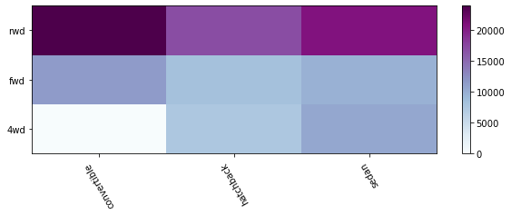

| body-style drive-wheels | price convertible | price hatchback | price sedan |
| --- | --- | --- | --- |
| 4wd | 0.0 | 7603.00 | 10617.857143 |
| fwd | 11595.0 | 8393.44 | 9845.029851 |
| rwd | 23949.6 | 17099.96 | 20768.311111 |

```python
grouped_pivot = df_group_one.pivot(index='drive-wheels',columns='body-style')
#fill missing values with 0
grouped_pivot = grouped_pivot.fillna(0)
fig_dims = (10, 3)
fig, ax = plt.subplots(figsize=fig_dims)
im = ax.pcolor(grouped_pivot, cmap='BuPu')

#label names
row_labels = grouped_pivot.columns.levels[1]
col_labels = grouped_pivot.index

#move ticks and labels to the center
ax.set_xticks(np.arange(grouped_pivot.shape[1]) + 0.5, minor=False)
ax.set_yticks(np.arange(grouped_pivot.shape[0]) + 0.5, minor=False)

#insert labels
ax.set_xticklabels(row_labels, minor=False)
ax.set_yticklabels(col_labels, minor=False)

plt.subplots
plt.xticks(rotation='120')
fig.colorbar(im)
plt.show()
grouped_pivot
```

```python
# grouping results
df_gptest = df[['drive-wheels','make','price']]
grouped_test_two = df_gptest.groupby(['drive-wheels','make'],as_index=False).mean()
grouped_test_two
```

|  | drive-wheels | make | price |
| --- | --- | --- | --- |
| 0 | 4wd | audi | 17450.000000 |
| 1 | 4wd | subaru | 9560.400000 |
| 2 | 4wd | toyota | 8338.000000 |
| 3 | fwd | audi | 17941.000000 |
| 4 | fwd | chevrolet | 6007.000000 |
| 5 | fwd | dodge | 7875.444444 |
| 6 | fwd | honda | 8184.692308 |
| 7 | fwd | mazda | 8399.545455 |
| 8 | fwd | mitsubishi | 9239.769231 |
| 9 | fwd | nissan | 8812.333333 |
| 10 | fwd | plymouth | 7163.333333 |
| 11 | fwd | renault | 9595.000000 |
| 12 | fwd | saab | 15223.333333 |
| 13 | fwd | subaru | 7813.285714 |
| 14 | fwd | toyota | 8253.000000 |
| 15 | fwd | volkswagen | 10077.500000 |
| 16 | rwd | alfa-romero | 15498.333333 |
| 17 | rwd | bmw | 26118.750000 |
| 18 | rwd | isuzu | 8916.500000 |
| 19 | rwd | jaguar | 34600.000000 |
| 20 | rwd | mazda | 14784.000000 |
| 21 | rwd | mercedes-benz | 33647.000000 |
| 22 | rwd | mercury | 16503.000000 |
| 23 | rwd | nissan | 18432.333333 |
| 24 | rwd | peugot | 15489.090909 |
| 25 | rwd | plymouth | 12764.000000 |
| 26 | rwd | porsche | 31400.500000 |
| 27 | rwd | toyota | 11973.000000 |
| 28 | rwd | volvo | 18063.181818 |

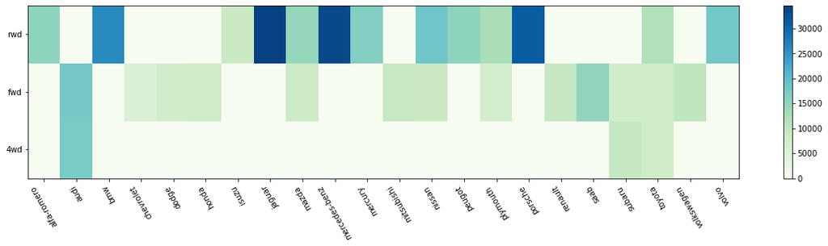

| make drive-wheels | price alfa-romero | price audi | price bmw | price chevrolet | price dodge | price honda | price isuzu | price jaguar | price mazda | price mercedes-benz | price ... | price nissan | price peugot | price plymouth | price porsche | price renault | price saab | price subaru | price toyota | price volkswagen | price volvo |
| --- | --- | --- | --- | --- | --- | --- | --- | --- | --- | --- | --- | --- | --- | --- | --- | --- | --- | --- | --- | --- | --- |
| 4wd | 0.000000 | 17450.0 | 0.00 | 0.0 | 0.000000 | 0.000000 | 0.0 | 0.0 | 0.000000 | 0.0 | ... | 0.000000 | 0.000000 | 0.000000 | 0.0 | 0.0 | 0.000000 | 9560.400000 | 8338.0 | 0.0 | 0.000000 |
| fwd | 0.000000 | 17941.0 | 0.00 | 6007.0 | 7875.444444 | 8184.692308 | 0.0 | 0.0 | 8399.545455 | 0.0 | ... | 8812.333333 | 0.000000 | 7163.333333 | 0.0 | 9595.0 | 15223.333333 | 7813.285714 | 8253.0 | 10077.5 | 0.000000 |
| rwd | 15498.333333 | 0.0 | 26118.75 | 0.0 | 0.000000 | 0.000000 | 8916.5 | 34600.0 | 14784.000000 | 33647.0 | ... | 18432.333333 | 15489.090909 | 12764.000000 | 31400.5 | 0.0 | 0.000000 | 0.000000 | 11973.0 | 0.0 | 18063.181818 |

3 rows × 22 columns

```python
grouped_pivot = grouped_test_two.pivot(index='drive-wheels',columns='make')
grouped_pivot = grouped_pivot.fillna(0) #fill missing values with 0
fig_size=(20,4)
fig, ax = plt.subplots(figsize=fig_size)
im = ax.pcolor(grouped_pivot, cmap='GnBu')

#label names
row_labels = grouped_pivot.columns.levels[1]
col_labels = grouped_pivot.index

#move ticks and labels to the center
ax.set_xticks(np.arange(grouped_pivot.shape[1]) + 0.5, minor=False)
ax.set_yticks(np.arange(grouped_pivot.shape[0]) + 0.5, minor=False)

#insert labels
ax.set_xticklabels(row_labels, minor=False)
ax.set_yticklabels(col_labels, minor=False)

plt.subplots
plt.xticks(rotation='120')

fig.colorbar(im)
plt.show()
grouped_pivot
```

**3.Pearson Correlation**

The Pearson Correlation measures the linear dependence between two variables X and Y.

The resulting coefficient is a value between -1 and 1 inclusive, where:

- **1**: Total positive linear correlation.
- **0**: No linear correlation, the two variables most likely do not affect each other.
- **-1**: Total negative linear correlation.

By convention, when the

- p-value is $<$ 0.001: we say there is strong evidence that the correlation is significant.
- the p-value is $<$ 0.05: there is moderate evidence that the correlation is significant.
- the p-value is $<$ 0.1: there is weak evidence that the correlation is significant.
- the p-value is $>$ 0.1: there is no evidence that the correlation is significant.

```python
from scipy import stats
```

```python
pearson_coef, p_value = stats.pearsonr(df['wheel-base'], df['price'])
print("The Pearson Correlation Coefficient for wheel-base & price is", pearson_coef, " with a P-value of P =", p_value)
pearson_coef, p_value = stats.pearsonr(df['horsepower'], df['price'])
print("The Pearson Correlation Coefficient for horse power & price is", pearson_coef, " with a P-value of P = ", p_value)
pearson_coef, p_value = stats.pearsonr(df['length'], df['price'])
print("The Pearson Correlation Coefficient for lengh & price is", pearson_coef, " with a P-value of P = ", p_value)
pearson_coef, p_value = stats.pearsonr(df['width'], df['price'])
print("The Pearson Correlation Coefficient for width & price is", pearson_coef, " with a P-value of P =", p_value)
pearson_coef, p_value = stats.pearsonr(df['curb-weight'], df['price'])
print( "The Pearson Correlation Coefficient for cuurb-weight & price is", pearson_coef, " with a P-value of P = ", p_value)
pearson_coef, p_value = stats.pearsonr(df['city-L/100km'], df['price'])
print("The Pearson Correlation Coefficient for city-L/100km & a price is", pearson_coef, " with a P-value of P = ", p_value)
```

```
The Pearson Correlation Coefficient for wheel-base & price is 0.5846418222655083  with a P-value of P = 8.076488270732873e-20
The Pearson Correlation Coefficient for horse power & price is 0.8095745670036555  with a P-value of P =  6.369057428261186e-48
The Pearson Correlation Coefficient for lengh & price is 0.6906283804483643  with a P-value of P =  8.01647746615853e-30
The Pearson Correlation Coefficient for width & price is 0.7512653440522675  with a P-value of P = 9.200335510481123e-38
The Pearson Correlation Coefficient for cuurb-weight & price is 0.8344145257702847  with a P-value of P =  2.189577238893567e-53
The Pearson Correlation Coefficient for city-L/100km & a price is 0.7898975136626946  with a P-value of P =  3.9031064009392475e-44
```

**ANOVA: Analysis of Variance**

The Analysis of Variance (ANOVA) is a statistical method used to test whether there are significant differences between the means of two or more groups. ANOVA returns two parameters:

**F-test score**: ANOVA assumes the means of all groups are the same, calculates how much the actual means deviate from the assumption, and reports it as the F-test score. A larger score means there is a larger difference between the means.

**P-value**: P-value tells how statistically significant is our calculated score value.

If our price variable is strongly correlated with the variable we are analyzing, expect ANOVA to return a sizeable F-test score and a small p-value.

```python
grouped_test2=df_gptest[['make', 'price']].groupby(['make'])
# ANOVA
f_val, p_val = stats.f_oneway(grouped_test2.get_group('audi')['price'], grouped_test2.get_group('honda')['price'], grouped_test2.get_group('jaguar')['price'])

print( "ANOVA results: F=", f_val, ", P =", p_val)
```

```
ANOVA results: F= 143.5625920787405 , P = 3.4050080642411477e-12
```

```python
grouped_test3=df_gptest[['drive-wheels', 'price']].groupby(['drive-wheels'])
grouped_test3.head(2)
grouped_test3.get_group('4wd')['price']
# ANOVA
f_val, p_val = stats.f_oneway(grouped_test3.get_group('fwd')['price'], grouped_test3.get_group('rwd')['price'], grouped_test3.get_group('4wd')['price'])
print( "ANOVA results: F=", f_val, ", P =", p_val)
f_val, p_val = stats.f_oneway(grouped_test3.get_group('fwd')['price'], grouped_test3.get_group('rwd')['price'])
print( "ANOVA results: F=", f_val, ", P =", p_val )
f_val, p_val = stats.f_oneway(grouped_test3.get_group('4wd')['price'], grouped_test3.get_group('rwd')['price'])
print( "ANOVA results: F=", f_val, ", P =", p_val)
f_val, p_val = stats.f_oneway(grouped_test3.get_group('4wd')['price'], grouped_test3.get_group('fwd')['price'])
print("ANOVA results: F=", f_val, ", P =", p_val)
```

```
ANOVA results: F= 67.95406500780399 , P = 3.3945443577151245e-23
ANOVA results: F= 130.5533160959111 , P = 2.2355306355677845e-23
ANOVA results: F= 8.580681368924756 , P = 0.004411492211225333
ANOVA results: F= 0.665465750252303 , P = 0.41620116697845666
```

#### Conclusion: Important Variables

We have a better idea of which variables are important to take into account when predicting the car price.  
We narrowed it down to the following variables:

Continuous numerical variables:

- Length
- Width
- height
- Curb-weight
- Engine-size
- Horsepower
- City--L/100km
- Highway--L/100km
- Wheel-base
- Bore

Categorical variables:

- Drive-wheels
- Make

As we now move into building machine learning models to automate analysis, feeding the model with variables that meaningfully affect our target variable will improve our model's prediction performance.

# 3. Dimention Reductionality and Principle Component Analysis(PCA)

Creating a new pandas dataframe to apply PCA to the selected Continuous numerical variables to fit a model to predict car price:

- Length
- Width
- height
- Curb-weight
- Engine-size
- Horsepower
- City--L/100km
- Highway--L/100km
- Wheel-base
- Bore

```python
df_pca = df[['length','width','height','curb-weight','engine-size',
             'horsepower','city-L/100km','highway-L/100km','wheel-base','bore']]
df_pca.head()
```

|  | length | width | height | curb-weight | engine-size | horsepower | city-L/100km | highway-L/100km | wheel-base | bore |
| --- | --- | --- | --- | --- | --- | --- | --- | --- | --- | --- |
| 0 | 0.811148 | 0.890278 | 0.816054 | 2548 | 130 | 111.0 | 11.190476 | 8.703704 | 88.6 | 3.47 |
| 1 | 0.811148 | 0.890278 | 0.816054 | 2548 | 130 | 111.0 | 11.190476 | 8.703704 | 88.6 | 3.47 |
| 2 | 0.822681 | 0.909722 | 0.876254 | 2823 | 152 | 154.0 | 12.368421 | 9.038462 | 94.5 | 2.68 |
| 3 | 0.848630 | 0.919444 | 0.908027 | 2337 | 109 | 102.0 | 9.791667 | 7.833333 | 99.8 | 3.19 |
| 4 | 0.848630 | 0.922222 | 0.908027 | 2824 | 136 | 115.0 | 13.055556 | 10.681818 | 99.4 | 3.19 |

**Step1:**

- Examining the correlation.
- Performing logarighmic transformations
- scaling data using standard scaler scaling method.
- Viewing the pairwise correlation plots of the new data.

```python
corr_mat = df_pca.corr()
for x in range(corr_mat.shape[0]):
    corr_mat.iloc[x,x] = 0.0
corr_mat
```

|  | length | width | height | curb-weight | engine-size | horsepower | city-L/100km | highway-L/100km | wheel-base | bore |
| --- | --- | --- | --- | --- | --- | --- | --- | --- | --- | --- |
| length | 0.000000 | 0.857170 | 0.492063 | 0.880665 | 0.685025 | 0.579821 | 0.657373 | 0.707108 | 0.876024 | 0.608971 |
| width | 0.857170 | 0.000000 | 0.306002 | 0.866201 | 0.729436 | 0.615077 | 0.673363 | 0.736728 | 0.814507 | 0.544885 |
| height | 0.492063 | 0.306002 | 0.000000 | 0.307581 | 0.074694 | -0.087027 | 0.003811 | 0.084301 | 0.590742 | 0.180449 |
| curb-weight | 0.880665 | 0.866201 | 0.307581 | 0.000000 | 0.849072 | 0.757976 | 0.785353 | 0.836921 | 0.782097 | 0.644060 |
| engine-size | 0.685025 | 0.729436 | 0.074694 | 0.849072 | 0.000000 | 0.822676 | 0.745059 | 0.783465 | 0.572027 | 0.572609 |
| horsepower | 0.579821 | 0.615077 | -0.087027 | 0.757976 | 0.822676 | 0.000000 | 0.889488 | 0.840608 | 0.371147 | 0.566936 |
| city-L/100km | 0.657373 | 0.673363 | 0.003811 | 0.785353 | 0.745059 | 0.889488 | 0.000000 | 0.958306 | 0.476153 | 0.554610 |
| highway-L/100km | 0.707108 | 0.736728 | 0.084301 | 0.836921 | 0.783465 | 0.840608 | 0.958306 | 0.000000 | 0.577576 | 0.559112 |
| wheel-base | 0.876024 | 0.814507 | 0.590742 | 0.782097 | 0.572027 | 0.371147 | 0.476153 | 0.577576 | 0.000000 | 0.493244 |
| bore | 0.608971 | 0.544885 | 0.180449 | 0.644060 | 0.572609 | 0.566936 | 0.554610 | 0.559112 | 0.493244 | 0.000000 |

```python
print("The highest correlation with each feature to other")
corr_mat.abs().idxmax()
```

```
The highest correlation with each feature to other
```

```
length                 curb-weight
width                  curb-weight
height                  wheel-base
curb-weight                 length
engine-size            curb-weight
horsepower            city-L/100km
city-L/100km       highway-L/100km
highway-L/100km       city-L/100km
wheel-base                  length
bore                   curb-weight
dtype: object
```

```python
# The log transformations
pca_array = df_pca.values
pca_array = np.log1p(pca_array)
print("Transformed data")
pd.DataFrame(pca_array)
```

```
Transformed data
```

|  | 0 | 1 | 2 | 3 | 4 | 5 | 6 | 7 | 8 | 9 |
| --- | --- | --- | --- | --- | --- | --- | --- | --- | --- | --- |
| 0 | 0.593961 | 0.636724 | 0.596666 | 7.843456 | 4.875197 | 4.718499 | 2.500655 | 2.272508 | 4.495355 | 1.497388 |
| 1 | 0.593961 | 0.636724 | 0.596666 | 7.843456 | 4.875197 | 4.718499 | 2.500655 | 2.272508 | 4.495355 | 1.497388 |
| 2 | 0.600309 | 0.646958 | 0.629277 | 7.945910 | 5.030438 | 5.043425 | 2.592895 | 2.306424 | 4.559126 | 1.302913 |
| 3 | 0.614445 | 0.652036 | 0.646070 | 7.757051 | 4.700480 | 4.634729 | 2.378774 | 2.178532 | 4.613138 | 1.432701 |
| 4 | 0.614445 | 0.653482 | 0.646070 | 7.946264 | 4.919981 | 4.753590 | 2.643018 | 2.458034 | 4.609162 | 1.432701 |
| ... | ... | ... | ... | ... | ... | ... | ... | ... | ... | ... |
| 196 | 0.645666 | 0.671384 | 0.656532 | 7.990577 | 4.955827 | 4.744932 | 2.417465 | 2.239950 | 4.701389 | 1.564441 |
| 197 | 0.645666 | 0.670674 | 0.656532 | 8.022897 | 4.955827 | 5.081404 | 2.592895 | 2.341806 | 4.701389 | 1.564441 |
| 198 | 0.645666 | 0.671384 | 0.656532 | 8.010692 | 5.159055 | 4.905275 | 2.643018 | 2.417465 | 4.701389 | 1.521699 |
| 199 | 0.645666 | 0.671384 | 0.656532 | 8.076515 | 4.983607 | 4.672829 | 2.306424 | 2.272508 | 4.701389 | 1.388791 |
| 200 | 0.645666 | 0.671384 | 0.656532 | 8.027150 | 4.955827 | 4.744932 | 2.592895 | 2.341806 | 4.701389 | 1.564441 |

201 rows × 10 columns

```python
from sklearn.preprocessing import StandardScaler
std = StandardScaler()
pca_array= std.fit_transform(pca_array)
print("Scaled data")
pd.DataFrame(pca_array)
```

```
Scaled data
```

|  | 0 | 1 | 2 | 3 | 4 | 5 | 6 | 7 | 8 | 9 |
| --- | --- | --- | --- | --- | --- | --- | --- | --- | --- | --- |
| 0 | -0.427017 | -0.856884 | -2.068800 | 0.084175 | 0.238187 | 0.383750 | 0.587514 | 0.456962 | -1.794724 | 0.541387 |
| 1 | -0.427017 | -0.856884 | -2.068800 | 0.084175 | 0.238187 | 0.383750 | 0.587514 | 0.456962 | -1.794724 | 0.541387 |
| 2 | -0.229349 | -0.179447 | -0.552264 | 0.607508 | 0.794608 | 1.361907 | 0.992222 | 0.629283 | -0.715084 | -2.594173 |
| 3 | 0.210871 | 0.156688 | 0.228627 | -0.357184 | -0.388042 | 0.131570 | 0.052756 | -0.020508 | 0.199340 | -0.501582 |
| 4 | 0.210871 | 0.252415 | 0.228627 | 0.609316 | 0.398703 | 0.489389 | 1.212137 | 1.399583 | 0.132024 | -0.501582 |
| ... | ... | ... | ... | ... | ... | ... | ... | ... | ... | ... |
| 196 | 1.183108 | 1.437455 | 0.715149 | 0.835669 | 0.527184 | 0.463325 | 0.222515 | 0.291540 | 1.693422 | 1.622478 |
| 197 | 1.183108 | 1.390459 | 0.715149 | 1.000760 | 0.527184 | 1.476240 | 0.992222 | 0.809052 | 1.693422 | 1.622478 |
| 198 | 1.183108 | 1.437455 | 0.715149 | 0.938415 | 1.255605 | 0.946020 | 1.212137 | 1.193464 | 1.693422 | 0.933350 |
| 199 | 1.183108 | 1.437455 | 0.715149 | 1.274643 | 0.626753 | 0.246265 | -0.264684 | 0.456962 | 1.693422 | -1.209542 |
| 200 | 1.183108 | 1.437455 | 0.715149 | 1.022485 | 0.527184 | 0.463325 | 0.992222 | 0.809052 | 1.693422 | 1.622478 |

201 rows × 10 columns

```
Pair plots
```

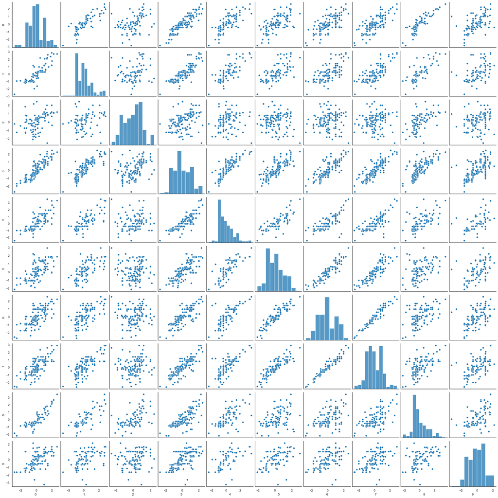

```python
sns.set_context('notebook')
sns.set_style('white')
print("Pair plots")
sns.pairplot(pd.DataFrame(pca_array))
plt.title="pair plot"
```

**Step2: Calculaing covariance matrix**

For this we used **cov()**method from numpy

```python
cov_matrix=np.cov(pca_array.T)
print("Covariance matrix:","\n",cov_matrix)
```

```
Covariance matrix:
 [[ 1.005       0.85882136  0.4909846   0.89519177  0.73472009  0.63113161
   0.67270083  0.7142403   0.878213    0.61507442]
 [ 0.85882136  1.005       0.3055248   0.86354415  0.75368545  0.65078191
   0.66791384  0.72420431  0.81644799  0.54746805]
 [ 0.4909846   0.3055248   1.005       0.31106573  0.12671334 -0.05950736
   0.02176891  0.09207079  0.5980092   0.17857248]
 [ 0.89519177  0.86354415  0.31106573  1.005       0.86703915  0.79413037
   0.80162687  0.84096308  0.7721713   0.66831594]
 [ 0.73472009  0.75368545  0.12671334  0.86703915  1.005       0.81766983
   0.72108543  0.74634153  0.59520332  0.62775695]
 [ 0.63113161  0.65078191 -0.05950736  0.79413037  0.81766983  1.005
   0.90967468  0.87870968  0.42054229  0.60363454]
 [ 0.67270083  0.66791384  0.02176891  0.80162687  0.72108543  0.90967468
   1.005       0.97056406  0.47995601  0.57753716]
 [ 0.7142403   0.72420431  0.09207079  0.84096308  0.74634153  0.87870968
   0.97056406  1.005       0.56840605  0.58467952]
 [ 0.878213    0.81644799  0.5980092   0.7721713   0.59520332  0.42054229
   0.47995601  0.56840605  1.005       0.49456894]
 [ 0.61507442  0.54746805  0.17857248  0.66831594  0.62775695  0.60363454
   0.57753716  0.58467952  0.49456894  1.005     ]]
```

**Step3: Finding out the eigen values and eigen vectors**

There are two ways :

- by singular value decomposition

For this we used **svd()**method from linear algebra(linalg) package of numpy library

- by eigen decomposition

For this we used **eig()**method from linear algebra(linalg) package of numpy library

Although both of them gives almost same result but svd is computationally more efficeint.For our project we have tried both but for further computaton we will use eigen values and vectors that are computed by svd() method.

```python
eigen_vectors_svd,eigen_values_svd,v= np.linalg.svd(cov_matrix)
print("The eigen vectors are \n",eigen_vectors_svd)
print("The eigen values are\n",eigen_values_svd)
```

```
The eigen vectors are
 [[-3.48066730e-01  2.41811011e-01 -4.89977857e-02  8.98293336e-02
  -1.12998086e-01 -4.01812428e-01 -6.63828636e-01  2.26966368e-02
   4.11635132e-01 -1.58297261e-01]
 [-3.39699987e-01  1.29059902e-01 -2.03611511e-01  4.30697360e-01
  -2.57948071e-01  7.50449040e-01 -8.08626721e-02 -2.75933932e-02
   5.95564225e-02  2.07724514e-02]
 [-1.16614857e-01  6.84507547e-01  3.18779764e-02 -5.58509862e-01
   3.54829544e-01  2.79497152e-01  2.84267729e-03 -2.89138204e-02
   3.24303001e-03  4.86334371e-03]
 [-3.69848365e-01  2.95587395e-02 -3.36411683e-02  9.26429275e-02
   1.24576087e-01 -1.36811857e-01 -1.78755098e-01  4.83068828e-01
  -7.39960626e-01  7.44092497e-02]
 [-3.35461297e-01 -1.19888256e-01  6.98329960e-02  3.45754743e-01
   7.10406977e-01 -5.95053350e-02  2.99140385e-01  1.36728165e-01
   3.57378140e-01  6.74676282e-02]
 [-3.24770438e-01 -3.55336871e-01 -4.71164679e-02 -1.50808267e-01
   2.51861461e-01  5.20190964e-02 -2.07322886e-01 -7.27339293e-01
  -2.77446455e-01 -1.67853602e-01]
 [-3.31046934e-01 -2.97734432e-01 -1.83243243e-01 -4.16789918e-01
  -1.77530601e-01 -1.87306483e-03  1.18317918e-02  8.33245171e-02
   2.03833029e-01  7.17160177e-01]
 [-3.43286781e-01 -2.25409570e-01 -2.09670000e-01 -3.57011940e-01
  -2.04714974e-01  1.47795519e-02  3.34008741e-01  2.83740359e-01
   1.30474553e-01 -6.39300385e-01]
 [-3.01992932e-01  4.16154787e-01 -1.19724548e-01  2.00078874e-01
  -2.90818498e-01 -4.05595169e-01  5.23299455e-01 -3.59670696e-01
  -1.25580497e-01  1.14853420e-01]
 [-2.76439679e-01 -4.65737855e-02  9.24674788e-01 -4.92148819e-02
  -2.30560223e-01  8.69517871e-02  5.30980788e-02  5.92375772e-04
   2.04856191e-02 -2.89316989e-03]]
The eigen values are
 [6.85059132 1.56981118 0.53928703 0.42091958 0.27703121 0.12163323
 0.10173245 0.08695468 0.05858952 0.0234498 ]
```

```python
eigen_values,eigen_vectors= np.linalg.eig(cov_matrix)
print("The eigen vectors are \n",eigen_vectors)
print("The eigen values are\n", sorted(eigen_values, reverse=True))
```

```
The eigen vectors are
 [[ 3.48066730e-01  2.41811011e-01 -4.89977857e-02  8.98293336e-02
  -1.12998086e-01 -1.58297261e-01 -4.11635132e-01 -4.01812428e-01
   6.63828636e-01 -2.26966368e-02]
 [ 3.39699987e-01  1.29059902e-01 -2.03611511e-01  4.30697360e-01
  -2.57948071e-01  2.07724514e-02 -5.95564225e-02  7.50449040e-01
   8.08626721e-02  2.75933932e-02]
 [ 1.16614857e-01  6.84507547e-01  3.18779764e-02 -5.58509862e-01
   3.54829544e-01  4.86334371e-03 -3.24303001e-03  2.79497152e-01
  -2.84267729e-03  2.89138204e-02]
 [ 3.69848365e-01  2.95587395e-02 -3.36411683e-02  9.26429275e-02
   1.24576087e-01  7.44092497e-02  7.39960626e-01 -1.36811857e-01
   1.78755098e-01 -4.83068828e-01]
 [ 3.35461297e-01 -1.19888256e-01  6.98329960e-02  3.45754743e-01
   7.10406977e-01  6.74676282e-02 -3.57378140e-01 -5.95053350e-02
  -2.99140385e-01 -1.36728165e-01]
 [ 3.24770438e-01 -3.55336871e-01 -4.71164679e-02 -1.50808267e-01
   2.51861461e-01 -1.67853602e-01  2.77446455e-01  5.20190964e-02
   2.07322886e-01  7.27339293e-01]
 [ 3.31046934e-01 -2.97734432e-01 -1.83243243e-01 -4.16789918e-01
  -1.77530601e-01  7.17160177e-01 -2.03833029e-01 -1.87306483e-03
  -1.18317918e-02 -8.33245171e-02]
 [ 3.43286781e-01 -2.25409570e-01 -2.09670000e-01 -3.57011940e-01
  -2.04714974e-01 -6.39300385e-01 -1.30474553e-01  1.47795519e-02
  -3.34008741e-01 -2.83740359e-01]
 [ 3.01992932e-01  4.16154787e-01 -1.19724548e-01  2.00078874e-01
  -2.90818498e-01  1.14853420e-01  1.25580497e-01 -4.05595169e-01
  -5.23299455e-01  3.59670696e-01]
 [ 2.76439679e-01 -4.65737855e-02  9.24674788e-01 -4.92148819e-02
  -2.30560223e-01 -2.89316989e-03 -2.04856191e-02  8.69517871e-02
  -5.30980788e-02 -5.92375772e-04]]
The eigen values are
 [6.85059132091726, 1.5698111796094543, 0.5392870335000136, 0.4209195817465655, 0.2770312082192729, 0.12163322625697445, 0.10173244816528251, 0.08695467560665367, 0.05858952448552398, 0.023449801493007495]
```

**Step 4:**

In this step we calculated the variance captured by the princepal components.

The first principal component captures the most variance of the data set which is in our case almost 68%.

```python
variance_explained = [(i/sum(eigen_values_svd))*100 for i in eigen_values_svd]
variance_explained
```

```
[68.1650877703209,
 15.620011737407511,
 5.366040134328483,
 4.188254544741935,
 2.7565294350176357,
 1.2102808582783517,
 1.012263165823705,
 0.8652206528025225,
 0.5829803431395427,
 0.23333135813937783]
```

**Step 5:**

In this step we calculated the cumulative variance captured by the princepal components.

For this we used **cumcum()** method from numpy for visualization.

```python
cumulative_variance_explained=np.cumsum(variance_explained)
cumulative_variance_explained
```

```
array([ 68.16508777,  83.78509951,  89.15113964,  93.33939419,
        96.09592362,  97.30620448,  98.31846765,  99.1836883 ,
        99.76666864, 100.        ])
```

here, we used lineplot from seaborn library to understand the sharp edges, like first five pcs covers more than **95%**variance of the data set which is a good measure to to work with

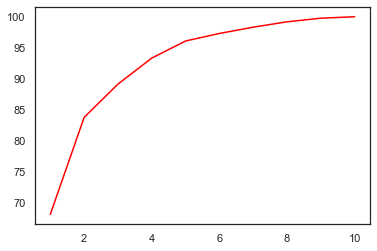

```python
sns.lineplot(x=[1,2,3,4,5,6,7,8,9,10],y=cumulative_variance_explained,color="red")
ax.set(xlabel='Number of dimensions',
       ylabel='Percent explained variance',
       title='Explained Variance vs Dimensions');
```

Here a histogram is used only first 5 principal component for visualization

```
(60.0, 100.0)
```

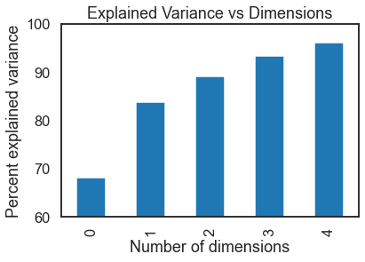

```python
d = {'number_of_components': [1, 2,3,4,5,6,7,8,9,10], 'explained_variance': cumulative_variance_explained}
df_explained_variance = pd.DataFrame(data=d)
df_explained_variance_cut=df_explained_variance.iloc[:5]
sns.set_context('talk')
ax = df_explained_variance_cut['explained_variance'].plot(kind='bar')
ax.set(xlabel='Number of dimensions',
       ylabel='Percent explained variance',
       title='Explained Variance vs Dimensions');
plt.ylim(60,100)
```

**Step 6:** Calculating the projection matrix

Projection matrix which is nothing but a fancy term for storing eigen vectors of first n components. in our case n=5

```python
projection_matrix=eigen_vectors_svd.T[:][:][:5].T
print("projection matrix:\n",projection_matrix)
```

```
projection matrix:
 [[-0.34806673  0.24181101 -0.04899779  0.08982933 -0.11299809]
 [-0.33969999  0.1290599  -0.20361151  0.43069736 -0.25794807]
 [-0.11661486  0.68450755  0.03187798 -0.55850986  0.35482954]
 [-0.36984836  0.02955874 -0.03364117  0.09264293  0.12457609]
 [-0.3354613  -0.11988826  0.069833    0.34575474  0.71040698]
 [-0.32477044 -0.35533687 -0.04711647 -0.15080827  0.25186146]
 [-0.33104693 -0.29773443 -0.18324324 -0.41678992 -0.1775306 ]
 [-0.34328678 -0.22540957 -0.20967    -0.35701194 -0.20471497]
 [-0.30199293  0.41615479 -0.11972455  0.20007887 -0.2908185 ]
 [-0.27643968 -0.04657379  0.92467479 -0.04921488 -0.23056022]]
```

**Step 7:** The Final step applying PCA

This is the last step where we perform the dot product of the projection matrix and the actual data

Here we converted the numpy nd.array to a pandas data frame and merge it to the actual data set and dropped the columns with the Continuous numerical variables

```python
pca_array= pca_array.dot(projection_matrix)
pca_df=pd.DataFrame(pca_array)
pca_df.columns=["pc1","pc2","pc3","pc4","pc5"]
print(pca_df)
df = pd.concat([df,pca_df],axis=1)
```

```
          pc1       pc2       pc3       pc4       pc5
0    0.486271 -2.842409  0.637176 -0.013432  0.010828
1    0.486271 -2.842409  0.637176 -0.013432  0.010828
2   -0.339778 -1.631920 -2.625859 -0.317422  1.360532
3    0.134295  0.312154 -0.549263 -0.178460 -0.217643
4   -1.486792 -0.561694 -1.065326 -0.833309  0.050135
..        ...       ...       ...       ...       ...
196 -2.753560  1.255187  0.854636  0.577932 -0.621152
197 -3.560082  0.548256  0.561376 -0.085334 -0.575937
198 -3.639409  0.533525 -0.128363  0.065966 -0.170744
199 -1.991439  1.573022 -1.707057  0.969141  0.155179
200 -3.255117  0.914889  0.598801  0.089676 -0.840468

[201 rows x 5 columns]
```

```python
df.drop(columns={'length','width','height','curb-weight','engine-size',
             'horsepower','city-L/100km','highway-L/100km','wheel-base','bore'},inplace=True,axis=1)
df
```

|  | symboling | normalized-losses | make | aspiration | num-of-doors | drive-wheels | engine-location | engine-type | num-of-cylinders | fuel-system | ... | price | horsepower-binned | fuel-type-diesel | fuel-type-gas | body-style | pc1 | pc2 | pc3 | pc4 | pc5 |
| --- | --- | --- | --- | --- | --- | --- | --- | --- | --- | --- | --- | --- | --- | --- | --- | --- | --- | --- | --- | --- | --- |
| 0 | 3 | 122 | alfa-romero | std | two | rwd | front | dohc | four | mpfi | ... | 13495.0 | Low | 0 | 1 | convertible | 0.486271 | -2.842409 | 0.637176 | -0.013432 | 0.010828 |
| 1 | 3 | 122 | alfa-romero | std | two | rwd | front | dohc | four | mpfi | ... | 16500.0 | Low | 0 | 1 | convertible | 0.486271 | -2.842409 | 0.637176 | -0.013432 | 0.010828 |
| 2 | 1 | 122 | alfa-romero | std | two | rwd | front | ohcv | six | mpfi | ... | 16500.0 | Medium | 0 | 1 | hatchback | -0.339778 | -1.631920 | -2.625859 | -0.317422 | 1.360532 |
| 3 | 2 | 164 | audi | std | four | fwd | front | ohc | four | mpfi | ... | 13950.0 | Low | 0 | 1 | sedan | 0.134295 | 0.312154 | -0.549263 | -0.178460 | -0.217643 |
| 4 | 2 | 164 | audi | std | four | 4wd | front | ohc | five | mpfi | ... | 17450.0 | Low | 0 | 1 | sedan | -1.486792 | -0.561694 | -1.065326 | -0.833309 | 0.050135 |
| ... | ... | ... | ... | ... | ... | ... | ... | ... | ... | ... | ... | ... | ... | ... | ... | ... | ... | ... | ... | ... | ... |
| 196 | -1 | 95 | volvo | std | four | rwd | front | ohc | four | mpfi | ... | 16845.0 | Low | 0 | 1 | sedan | -2.753560 | 1.255187 | 0.854636 | 0.577932 | -0.621152 |
| 197 | -1 | 95 | volvo | turbo | four | rwd | front | ohc | four | mpfi | ... | 19045.0 | Medium | 0 | 1 | sedan | -3.560082 | 0.548256 | 0.561376 | -0.085334 | -0.575937 |
| 198 | -1 | 95 | volvo | std | four | rwd | front | ohcv | six | mpfi | ... | 21485.0 | Medium | 0 | 1 | sedan | -3.639409 | 0.533525 | -0.128363 | 0.065966 | -0.170744 |
| 199 | -1 | 95 | volvo | turbo | four | rwd | front | ohc | six | idi | ... | 22470.0 | Low | 1 | 0 | sedan | -1.991439 | 1.573022 | -1.707057 | 0.969141 | 0.155179 |
| 200 | -1 | 95 | volvo | turbo | four | rwd | front | ohc | four | mpfi | ... | 22625.0 | Low | 0 | 1 | sedan | -3.255117 | 0.914889 | 0.598801 | 0.089676 | -0.840468 |

201 rows × 23 columns

# 4.Model Development & Model Evaluation on Training data

In this section, we will develop several models that will predict the price of the car using the variables or features. This is just an estimate, give us an objective idea of how much the car should cost.

#### 1. Linear Regression and Multiple Linear Regression

**A)Simple Linear Regression**.

Simple Linear Regression is a method to help us understand the relationship between two variables:

- The predictor/independent variable (X)
- The response/dependent variable (that we want to predict)(Y)

The result of Linear Regression is a **linear function** that predicts the response (dependent) variable as a function of the predictor (independent) variable.

$$ Y: Response \ Variable\\ X: Predictor \ Variables $$ **Linear function:** $$ Yhat = a + b X $$

```python
df['price'] = (df['price']-df['price'].min())/df['price'].std()
from sklearn.linear_model import LinearRegression
lm = LinearRegression()
X = df[['pc1']]
Y = df['price']
lm.fit(X,Y)
print("Intercept:",lm.intercept_,"\nCoefficient:",lm.coef_)
Yhat=lm.predict(X)
Yhat[0:5]
```

```
Intercept: 1.017876157714306
Coefficient: [-0.31902459]
```

```
array([0.86274372, 0.86274372, 1.12627374, 0.97503277, 1.49219938])
```

##### Residual Plot

The difference between the observed value (y) and the predicted value (Yhat) is called the residual (e). When we look at a regression plot, the residual is the distance from the data point to the fitted regression line.

A residual plot is a graph that shows the residuals on the vertical y-axis and the independent variable on the horizontal x-axis.

- If the points in a residual plot are **randomly spread out around the x-axis**, then a **linear model is appropriate** for the data. Randomly spread out residuals means that the variance is constant, and thus the linear model is a good fit for this data.

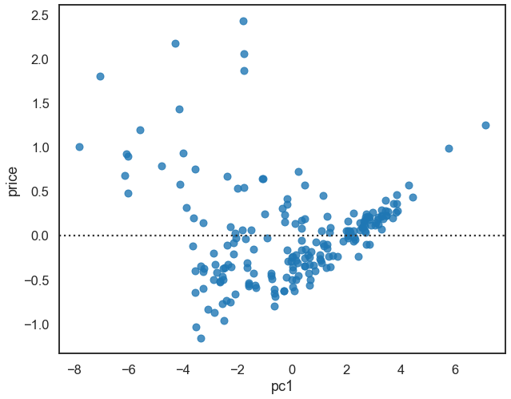

```python
plt.figure(figsize=(10, 8))
sns.residplot(X, Y)
plt.show()
```

We can see from this residual plot that the residuals are not randomly spread around the x-axis, which leads us to believe that maybe a non-linear model is more appropriate for this data.

#### B)Multiple Linear Regression

Multiple Linear Regression is very similar to Simple Linear Regression, but this method is used to explain the relationship between one continuous response (dependent) variable and **two or more** predictor (independent) variables. $$ Y: Response \ Variable\\ X_1 :Predictor\ Variable \ 1\\ X_2: Predictor\ Variable \ 2\\ X_3: Predictor\ Variable \ 3\\ X_4: Predictor\ Variable \ 4\\ $$ $$ a: intercept\\ b_1 :coefficients \ of\ Variable \ 1\\ b_2: coefficients \ of\ Variable \ 2\\ b_3: coefficients \ of\ Variable \ 3\\ b_4: coefficients \ of\ Variable \ 4\\ $$ **Multiple Linear function:** $$ Yhat = a + b_1 X_1 + b_2 X_2 + b_3 X_3 + b_4 X_4 $$

```python
lm = LinearRegression()
Z = df[['pc1','pc2','pc3','pc4','pc5']]
lm.fit(Z, df['price'])
print("Intercept:",lm.intercept_,"\nCoefficient:",lm.coef_)
Yhat=lm.predict(Z)
Yhat[0:5]
```

```
Intercept: 1.017876157714306
Coefficient: [-0.31902459 -0.1167457  -0.10726546  0.14298583  0.33407715]
```

```
array([1.12793263, 1.12793263, 2.00759313, 0.89928005, 1.56964479])
```

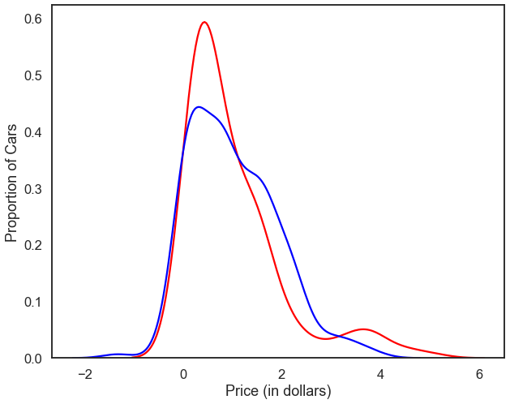

```python
plt.figure(figsize=(10,8))
ax1 = sns.kdeplot(df['price'], color="r", label="Actual Value" )
sns.kdeplot(Yhat, color="b", label="Fitted Values" , ax=ax1,)
plt.xlabel('Price (in dollars)')
plt.ylabel('Proportion of Cars')
plt.show()
plt.close()
```

We can see that the fitted values are reasonably close to the actual values, since the two distributions overlap a bit. However, there is definitely some room for improvement.

#### C)Polynomial regression

It is a particular case of the general linear regression model or multiple linear regression models.

We get non-linear relationships by squaring or setting higher-order terms of the predictor variables.

There are different orders of polynomial regression:

**Quadratic - 2nd order**

$$ Yhat = a + b_1 X +b_2 X^2 $$

**Cubic - 3rd order**

$$ Yhat = a + b_1 X +b_2 X^2 +b_3 X^3\\\\ $$

**Higher order**:

$$ Y = a + b_1 X +b_2 X^2 +b_3 X^3 ....\\\\ $$

```
            3           2
-0.0007727 x + 0.03007 x - 0.2793 x + 0.8086
```

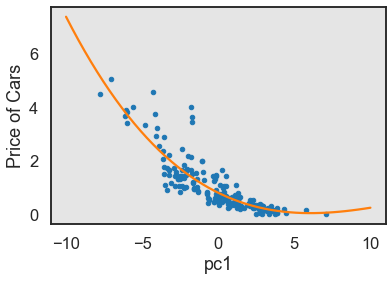

```python
# Here we use a polynomial of the 3rd order (cubic)
x=df["pc1"]
y=df["price"]
f = np.polyfit(x, y,3)
p = np.poly1d(f)
print(p)
def PlotPolly(model, independent_variable, dependent_variabble, Name):
    x_new = np.linspace(-10, 10)
    y_new = model(x_new)

    plt.plot(independent_variable, dependent_variabble, '.', x_new, y_new, '-')
    ax = plt.gca()
    ax.set_facecolor((0.898, 0.898, 0.898))
    fig = plt.gcf()
    plt.xlabel(Name)
    plt.ylabel('Price of Cars')

    plt.show()
    plt.close()
PlotPolly(p, x, y, 'pc1')
```

from plotting that this polynomial model performs better than the linear model.

**In-Sample Evaluation**

- R-squared

R squared, also known as the coefficient of determination, is a measure to indicate how close the data is to the fitted regression line.

The value of the R-squared is the percentage of variation of the response variable (y) that is explained by a linear model.

- Mean Squared Error (MSE)

The Mean Squared Error measures the average of the squares of errors, that is, the difference between actual value (y) and the estimated value (ŷ).

```python
lm.fit(X, Y)
# Finding the R^2
print('The R-square is: ', lm.score(X, Y))
from sklearn.metrics import mean_squared_error
mse = mean_squared_error(df['price'], Yhat)
print('The mean square error of price and predicted value is: ', mse)
```

```
The R-square is:  0.6972304887122021
The mean square error of price and predicted value is:  0.2344718983782016
```

- For MLR R<sup>2</sup> and MSE

```python
# fit the model
lm.fit(Z, df['price'])
# Finding the R^2
print('The R-square is: ', lm.score(Z, df['price']))
Y_predict_multifit = lm.predict(Z)
print('The mean square error of price and predicted value using multifit is: ', \
      mean_squared_error(df['price'], Y_predict_multifit))
```

```
The R-square is:  0.7643557421299076
The mean square error of price and predicted value using multifit is:  0.2344718983782016
```

```python
from sklearn.metrics import r2_score
r_squared = r2_score(y, p(x))
print('The R-square value is: ', r_squared)
print('The mean square error of price and predicted value using polyfit is: ', \
mean_squared_error(df['price'], p(x)))
```

```
The R-square value is:  0.7770283168501959
The mean square error of price and predicted value using polyfit is:  0.22186237129333763
```

# 5. Model Evaluation on Training and Testing Data

```python
df=df._get_numeric_data()
lr = LinearRegression()
df.head()
```

|  | symboling | normalized-losses | stroke | compression-ratio | peak-rpm | price | fuel-type-diesel | fuel-type-gas | pc1 | pc2 | pc3 | pc4 | pc5 |
| --- | --- | --- | --- | --- | --- | --- | --- | --- | --- | --- | --- | --- | --- |
| 0 | 3 | 122 | 2.68 | 9.0 | 5000.0 | 1.054100 | 0 | 1 | 0.486271 | -2.842409 | 0.637176 | -0.013432 | 0.010828 |
| 1 | 3 | 122 | 2.68 | 9.0 | 5000.0 | 1.432227 | 0 | 1 | 0.486271 | -2.842409 | 0.637176 | -0.013432 | 0.010828 |
| 2 | 1 | 122 | 3.47 | 9.0 | 5000.0 | 1.432227 | 0 | 1 | -0.339778 | -1.631920 | -2.625859 | -0.317422 | 1.360532 |
| 3 | 2 | 164 | 3.40 | 10.0 | 5500.0 | 1.111354 | 0 | 1 | 0.134295 | 0.312154 | -0.549263 | -0.178460 | -0.217643 |
| 4 | 2 | 164 | 3.40 | 8.0 | 5500.0 | 1.551768 | 0 | 1 | -1.486792 | -0.561694 | -1.065326 | -0.833309 | 0.050135 |

```python
%%capture
! pip install ipywidgets
from ipywidgets import interact, interactive, fixed, interact_manual
```

```python
def PollyPlot(xtrain, xtest, y_train, y_test, lr,poly_transform):
    plt.figure(figsize=(10,5))
    #training data
    #testing data
    # lr:  linear regression object
    #poly_transform:  polynomial transformation object
    xmax=max([xtrain.values.max(), xtest.values.max()])
    xmin=min([xtrain.values.min(), xtest.values.min()])
    x=np.arange(xmin, xmax, 0.1)


    plt.plot(xtrain, y_train, 'ro', label='Training Data')
    plt.plot(xtest, y_test, 'go', label='Test Data')
    plt.plot(x, lr.predict(poly_transform.fit_transform(x.reshape(-1, 1))), label='Predicted Function')
    plt.ylim([-1,10])
    plt.ylabel('Price')
    plt.legend()
```

```python
y_data = df['price']
x_data= df.drop('price',axis=1)
from sklearn.model_selection import train_test_split
x_train, x_test, y_train, y_test = train_test_split(x_data, y_data, test_size=0.45, random_state=1)
print("number of test samples :", x_test.shape[0])
print("number of training samples:",x_train.shape[0])
```

```
number of test samples : 91
number of training samples: 110
```

```python
from sklearn.preprocessing import PolynomialFeatures
pr = PolynomialFeatures(degree=5)
x_train_pr = pr.fit_transform(x_train[['pc1']])
x_test_pr = pr.fit_transform(x_test[['pc1']])
poly = LinearRegression()
poly.fit(x_train_pr, y_train)
```

```
LinearRegression()
```

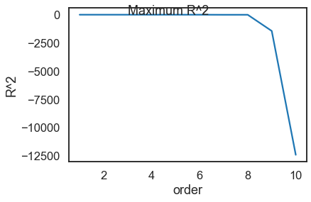

```python
Rsqu_test = []
order = [1, 2, 3, 4, 5,6,7,8,9,10]
for n in order:
    pr = PolynomialFeatures(degree=n)
    x_train_pr = pr.fit_transform(x_train[['pc1']])
    x_test_pr = pr.fit_transform(x_test[['pc1']])
    lr.fit(x_train_pr, y_train)
    Rsqu_test.append(lr.score(x_test_pr, y_test))

plt.plot(order, Rsqu_test)
plt.xlabel('order')
plt.ylabel('R^2')
plt.text(3, 0.75, 'Maximum R^2')
```

```python
def f(order, test_data):
    x_train, x_test, y_train, y_test = train_test_split(x_data, y_data, test_size=test_data, random_state=0)
    pr = PolynomialFeatures(degree=order)
    x_train_pr = pr.fit_transform(x_train[['pc1']])
    x_test_pr = pr.fit_transform(x_test[['pc1']])
    poly = LinearRegression()
    poly.fit(x_train_pr,y_train)
    PollyPlot(x_train[['pc1']], x_test[['pc1']], y_train,y_test, poly, pr)
interact(f, order=(0, 10, 1), test_data=(0.05, 0.95, 0.05))
```

```
<function __main__.f(order, test_data)>
```